# Incidence of youth-onset type 2 diabetes during the COVID-19 pandemic

Laura Pyle

24 January 2022

# 1 Background

The purpose of this analysis is to examine the frequency of diagnosis of youth-onset type 2 diabetes during the COVID pandemic (defined as March 1, 2020-February 28, 2021) compared to prior to the pandemic (March 1, 2018-February 28, 2020).

# 2 Outstanding data issues/questions

- CHOP and Vanderbilt data have been added to this report. Vanderbilt data were excluded in any analyses requiring month of diagnosis.
- Lorraine replied that the 4 patients at CHOP all had history of weight loss. Two had prior BMIp >85th, one reported weight loss but no BMI available, and another reported 50 lb weight loss and subsequent BMIp >85th. All are included in this version of the report.
- Queries were sent to the sites regarding patients with <2 antibodies tested. The 10 sites were CCHMC, CHLA, Duke, Michigan, Penn State, Pennington, TCH, UCSD, UCSF, and Vanderbilt. Duke, TCH, CHLA, Vanderbilt, UCSF, UCSD, Michigan confirmed these patients should be excluded. CCHMC and Pennington provided antibody results for some patients and confirmed that others should be excluded. Other sites are pending (data are included for now).
- The negative binomial time series model is not an individual-level model, so can’t test for interaction of sex and race. Added log-linear model testing homogeneity of association of sex and race by pandemic.

# 3 Methods

Lab values reported as either above or below the limit of detection were set to the limit of detection. DKA was defined as either pH<7.3 or bicarbonate<=15. HHS was defined as serum glucose >600 and osmolality >=330. Metabolic decompensation was defined as either DKA or HHS. DKA severity was defined as follows: 1) severe - pH <7.1 or bicarbonate <5, 2) moderate - pH <7.2 or bicarbonate <10, or 3) mild - pH <7.3 or bicarbonate <=15.

Groups were compared using either a t-test or ANOVA for normally distributed continuous variables, the Kruskal Wallis test for non-normally distributed variables, and the chi-square test for categorical variables.

A negative binomial time series model was used to model the count of youth-onset T2D diagnoses per month. A background linear trend of 5% increase per year was assumed. Seasonality was assessed by allowing the number of diagnoses in a particular month to depend on the number in the prior month, and the number 12 months prior; however, the amount of seasonality was minimal. Because there appeared to be a peak in the number of diagnoses in August during the first 2 years, less so in the 3rd year, a covariate corresponding to August vs. other months was tested but was not significant. The final model did not include any effect of seasonality. A test of intervention was performed to determine whether the onset of the pandemic in March 1, 2020, had a significant effect on the count of diagnoses.

# 4 Results

## 4.1 Summary of missing observations

### 4.1.1 All years combined

Data summary

| Name | alldata |
| --- | --- |
| Number of rows | 3113 |
| Number of columns | 44 |
| _______________________ |  |
| Column type frequency: |  |
| character | 19 |
| Date | 1 |
| factor | 4 |
| logical | 3 |
| numeric | 17 |
| ________________________ |  |
| Group variables | None |

**Variable type: character**

| skim_variable | n_missing | complete_rate | min | max | empty | n_unique | whitespace |
| --- | --- | --- | --- | --- | --- | --- | --- |
| ptid | 2250 | 0.28 | 1 | 10 | 0 | 577 | 0 |
| GAD65.Ab | 0 | 1.00 | 8 | 10 | 0 | 2 | 0 |
| Insulin.Ab | 0 | 1.00 | 8 | 10 | 0 | 2 | 0 |
| ICA.Ab | 139 | 0.96 | 8 | 10 | 0 | 2 | 0 |
| ZnT8.Ab | 0 | 1.00 | 8 | 10 | 0 | 2 | 0 |
| Race | 0 | 1.00 | 5 | 7 | 0 | 5 | 0 |
| Ethnicity | 0 | 1.00 | 7 | 12 | 0 | 3 | 0 |
| sex | 0 | 1.00 | 4 | 6 | 0 | 2 | 0 |
| insurance | 0 | 1.00 | 5 | 9 | 0 | 5 | 0 |
| Location.Diagnosis | 0 | 1.00 | 7 | 10 | 0 | 3 | 0 |
| COVID.19.at.diagnosis | 266 | 0.91 | 2 | 7 | 0 | 3 | 0 |
| site | 0 | 1.00 | 2 | 19 | 0 | 24 | 0 |
| region | 0 | 1.00 | 4 | 9 | 0 | 4 | 0 |
| race_eth | 0 | 1.00 | 5 | 8 | 0 | 6 | 0 |
| race_eth_black | 0 | 1.00 | 5 | 9 | 0 | 2 | 0 |
| race_eth_white | 0 | 1.00 | 5 | 9 | 0 | 2 | 0 |
| pHsev | 2712 | 0.13 | 4 | 8 | 0 | 3 | 0 |
| bicarbsev | 2714 | 0.13 | 4 | 8 | 0 | 3 | 0 |
| dka_severity | 2660 | 0.15 | 4 | 8 | 0 | 3 | 0 |

**Variable type: Date**

| skim_variable | n_missing | complete_rate | min | max | median | n_unique |
| --- | --- | --- | --- | --- | --- | --- |
| dx_date | 65 | 0.98 | 2018-03-01 | 2021-02-01 | 2020-01-01 | 36 |

**Variable type: factor**

| skim_variable | n_missing | complete_rate | ordered | n_unique | top_counts |
| --- | --- | --- | --- | --- | --- |
| mo_dx | 65 | 0.98 | FALSE | 12 | 8: 344, 10: 303, 9: 302, 1: 289 |
| yr_dx | 65 | 0.98 | FALSE | 4 | 202: 1307, 201: 837, 201: 627, 202: 277 |
| period | 0 | 1.00 | FALSE | 3 | 3/1: 1463, 3/1: 886, 3/1: 764 |
| pandemic | 0 | 1.00 | FALSE | 2 | 0: 1650, 1: 1463 |

**Variable type: logical**

| skim_variable | n_missing | complete_rate | mean | count |
| --- | --- | --- | --- | --- |
| dka | 0 | 1 | 0.15 | FAL: 2660, TRU: 453 |
| hhs | 0 | 1 | 0.02 | FAL: 3044, TRU: 69 |
| met_decomp | 0 | 1 | 0.15 | FAL: 2654, TRU: 459 |

**Variable type: numeric**

| skim_variable | n_missing | complete_rate | mean | sd | p0 | p25 | p50 | p75 | p100 | hist |
| --- | --- | --- | --- | --- | --- | --- | --- | --- | --- | --- |
| num_ab_tested | 139 | 0.96 | 3.37 | 0.63 | 2.00 | 3.00 | 3.00 | 4.00 | 5.00 | ▂▇▁▇▁ |
| age_dx | 22 | 0.99 | 14.38 | 2.35 | 5.00 | 12.80 | 14.50 | 16.10 | 21.80 | ▁▂▇▇▁ |
| BMI | 112 | 0.96 | 35.97 | 8.15 | 16.13 | 30.32 | 34.80 | 40.00 | 99.70 | ▆▇▁▁▁ |
| HbA1c | 14 | 1.00 | 10.12 | 3.20 | 5.30 | 7.40 | 10.00 | 12.30 | 105.00 | ▇▁▁▁▁ |
| Serum.glucose..random. | 193 | 0.94 | 311.13 | 221.32 | 63.00 | 154.00 | 265.00 | 381.25 | 2340.00 | ▇▁▁▁▁ |
| pH | 1837 | 0.41 | 7.30 | 0.20 | 3.49 | 7.24 | 7.36 | 7.39 | 7.51 | ▁▁▁▁▇ |
| bicarbonate | 1530 | 0.51 | 20.18 | 7.19 | 0.10 | 15.00 | 23.00 | 25.00 | 41.00 | ▂▃▇▇▁ |
| Serum.osmolality | 2657 | 0.15 | 312.16 | 32.15 | 240.00 | 293.00 | 299.50 | 318.00 | 446.00 | ▁▇▂▁▁ |
| gad_check | 0 | 1.00 | 0.99 | 0.08 | 0.00 | 1.00 | 1.00 | 1.00 | 1.00 | ▁▁▁▁▇ |
| ICA_check | 139 | 0.96 | 0.95 | 0.22 | 0.00 | 1.00 | 1.00 | 1.00 | 1.00 | ▁▁▁▁▇ |
| zn_check | 0 | 1.00 | 0.47 | 0.50 | 0.00 | 0.00 | 0.00 | 1.00 | 1.00 | ▇▁▁▁▇ |
| Insulin_check | 0 | 1.00 | 0.92 | 0.27 | 0.00 | 1.00 | 1.00 | 1.00 | 1.00 | ▁▁▁▁▇ |
| num_ab_check | 139 | 0.96 | 3.36 | 0.64 | 1.00 | 3.00 | 3.00 | 4.00 | 4.00 | ▁▂▁▇▇ |
| bmip | 142 | 0.95 | 0.98 | 0.03 | 0.24 | 0.98 | 0.99 | 1.00 | 1.00 | ▁▁▁▁▇ |
| perc_95 | 22 | 0.99 | 26.70 | 2.06 | 17.91 | 25.36 | 26.88 | 28.21 | 31.52 | ▁▁▅▇▂ |
| bmi_perc_of_95 | 132 | 0.96 | 134.96 | 30.42 | 65.84 | 114.57 | 130.98 | 149.90 | 432.38 | ▇▅▁▁▁ |
| day_dx | 0 | 1.00 | 1.00 | 0.00 | 1.00 | 1.00 | 1.00 | 1.00 | 1.00 | ▁▁▇▁▁ |

### 4.1.2 3/1/18-2/28/19

Data summary

| Name | alldata[alldata$period ==… |
| --- | --- |
| Number of rows | 764 |
| Number of columns | 44 |
| _______________________ |  |
| Column type frequency: |  |
| character | 19 |
| Date | 1 |
| factor | 4 |
| logical | 3 |
| numeric | 17 |
| ________________________ |  |
| Group variables | None |

**Variable type: character**

| skim_variable | n_missing | complete_rate | min | max | empty | n_unique | whitespace |
| --- | --- | --- | --- | --- | --- | --- | --- |
| ptid | 536 | 0.30 | 1 | 10 | 0 | 191 | 0 |
| GAD65.Ab | 0 | 1.00 | 8 | 10 | 0 | 2 | 0 |
| Insulin.Ab | 0 | 1.00 | 8 | 10 | 0 | 2 | 0 |
| ICA.Ab | 35 | 0.95 | 8 | 10 | 0 | 2 | 0 |
| ZnT8.Ab | 0 | 1.00 | 8 | 10 | 0 | 2 | 0 |
| Race | 0 | 1.00 | 5 | 7 | 0 | 5 | 0 |
| Ethnicity | 0 | 1.00 | 7 | 12 | 0 | 3 | 0 |
| sex | 0 | 1.00 | 4 | 6 | 0 | 2 | 0 |
| insurance | 0 | 1.00 | 5 | 9 | 0 | 5 | 0 |
| Location.Diagnosis | 0 | 1.00 | 7 | 10 | 0 | 3 | 0 |
| COVID.19.at.diagnosis | 122 | 0.84 | 2 | 7 | 0 | 2 | 0 |
| site | 0 | 1.00 | 2 | 19 | 0 | 24 | 0 |
| region | 0 | 1.00 | 4 | 9 | 0 | 4 | 0 |
| race_eth | 0 | 1.00 | 5 | 8 | 0 | 6 | 0 |
| race_eth_black | 0 | 1.00 | 5 | 9 | 0 | 2 | 0 |
| race_eth_white | 0 | 1.00 | 5 | 9 | 0 | 2 | 0 |
| pHsev | 703 | 0.08 | 4 | 8 | 0 | 3 | 0 |
| bicarbsev | 703 | 0.08 | 4 | 8 | 0 | 3 | 0 |
| dka_severity | 694 | 0.09 | 4 | 8 | 0 | 3 | 0 |

**Variable type: Date**

| skim_variable | n_missing | complete_rate | min | max | median | n_unique |
| --- | --- | --- | --- | --- | --- | --- |
| dx_date | 17 | 0.98 | 2018-03-01 | 2019-02-01 | 2018-08-01 | 12 |

**Variable type: factor**

| skim_variable | n_missing | complete_rate | ordered | n_unique | top_counts |
| --- | --- | --- | --- | --- | --- |
| mo_dx | 17 | 0.98 | FALSE | 12 | 8: 106, 1: 67, 3: 67, 9: 66 |
| yr_dx | 17 | 0.98 | FALSE | 2 | 201: 627, 201: 120, 202: 0, 202: 0 |
| period | 0 | 1.00 | FALSE | 1 | 3/1: 764, 3/1: 0, 3/1: 0 |
| pandemic | 0 | 1.00 | FALSE | 1 | 0: 764, 1: 0 |

**Variable type: logical**

| skim_variable | n_missing | complete_rate | mean | count |
| --- | --- | --- | --- | --- |
| dka | 0 | 1 | 0.09 | FAL: 694, TRU: 70 |
| hhs | 0 | 1 | 0.01 | FAL: 757, TRU: 7 |
| met_decomp | 0 | 1 | 0.09 | FAL: 692, TRU: 72 |

**Variable type: numeric**

| skim_variable | n_missing | complete_rate | mean | sd | p0 | p25 | p50 | p75 | p100 | hist |
| --- | --- | --- | --- | --- | --- | --- | --- | --- | --- | --- |
| num_ab_tested | 35 | 0.95 | 3.30 | 0.66 | 2.00 | 3.00 | 3.00 | 4.00 | 5.00 | ▂▇▁▇▁ |
| age_dx | 7 | 0.99 | 14.28 | 2.29 | 7.20 | 12.80 | 14.40 | 16.00 | 21.30 | ▁▃▇▆▁ |
| BMI | 30 | 0.96 | 35.58 | 8.29 | 16.13 | 29.60 | 34.62 | 39.22 | 97.78 | ▆▇▁▁▁ |
| HbA1c | 4 | 0.99 | 9.92 | 4.39 | 5.30 | 7.30 | 9.30 | 11.93 | 105.00 | ▇▁▁▁▁ |
| Serum.glucose..random. | 69 | 0.91 | 280.11 | 187.41 | 63.00 | 141.50 | 241.00 | 360.00 | 1500.00 | ▇▂▁▁▁ |
| pH | 503 | 0.34 | 7.33 | 0.12 | 6.82 | 7.30 | 7.37 | 7.40 | 7.51 | ▁▁▂▆▇ |
| bicarbonate | 409 | 0.46 | 21.54 | 6.51 | 2.00 | 20.00 | 23.00 | 26.00 | 41.00 | ▂▂▇▃▁ |
| Serum.osmolality | 642 | 0.16 | 305.48 | 25.48 | 284.00 | 292.00 | 298.00 | 307.00 | 437.00 | ▇▁▁▁▁ |
| gad_check | 0 | 1.00 | 0.99 | 0.07 | 0.00 | 1.00 | 1.00 | 1.00 | 1.00 | ▁▁▁▁▇ |
| ICA_check | 35 | 0.95 | 0.96 | 0.20 | 0.00 | 1.00 | 1.00 | 1.00 | 1.00 | ▁▁▁▁▇ |
| zn_check | 0 | 1.00 | 0.42 | 0.49 | 0.00 | 0.00 | 0.00 | 1.00 | 1.00 | ▇▁▁▁▆ |
| Insulin_check | 0 | 1.00 | 0.90 | 0.30 | 0.00 | 1.00 | 1.00 | 1.00 | 1.00 | ▁▁▁▁▇ |
| num_ab_check | 35 | 0.95 | 3.29 | 0.67 | 2.00 | 3.00 | 3.00 | 4.00 | 4.00 | ▂▁▇▁▇ |
| bmip | 38 | 0.95 | 0.98 | 0.04 | 0.24 | 0.98 | 0.99 | 1.00 | 1.00 | ▁▁▁▁▇ |
| perc_95 | 7 | 0.99 | 26.67 | 2.02 | 19.81 | 25.41 | 26.92 | 28.15 | 31.48 | ▁▂▆▇▂ |
| bmi_perc_of_95 | 37 | 0.95 | 133.88 | 31.11 | 65.84 | 112.63 | 129.77 | 148.36 | 377.87 | ▇▇▁▁▁ |
| day_dx | 0 | 1.00 | 1.00 | 0.00 | 1.00 | 1.00 | 1.00 | 1.00 | 1.00 | ▁▁▇▁▁ |

### 4.1.3 3/1/19-2/29/20

Data summary

| Name | alldata[alldata$period ==… |
| --- | --- |
| Number of rows | 886 |
| Number of columns | 44 |
| _______________________ |  |
| Column type frequency: |  |
| character | 19 |
| Date | 1 |
| factor | 4 |
| logical | 3 |
| numeric | 17 |
| ________________________ |  |
| Group variables | None |

**Variable type: character**

| skim_variable | n_missing | complete_rate | min | max | empty | n_unique | whitespace |
| --- | --- | --- | --- | --- | --- | --- | --- |
| ptid | 646 | 0.27 | 1 | 10 | 0 | 230 | 0 |
| GAD65.Ab | 0 | 1.00 | 8 | 10 | 0 | 2 | 0 |
| Insulin.Ab | 0 | 1.00 | 8 | 10 | 0 | 2 | 0 |
| ICA.Ab | 42 | 0.95 | 8 | 10 | 0 | 2 | 0 |
| ZnT8.Ab | 0 | 1.00 | 8 | 10 | 0 | 2 | 0 |
| Race | 0 | 1.00 | 5 | 7 | 0 | 5 | 0 |
| Ethnicity | 0 | 1.00 | 7 | 12 | 0 | 3 | 0 |
| sex | 0 | 1.00 | 4 | 6 | 0 | 2 | 0 |
| insurance | 0 | 1.00 | 5 | 9 | 0 | 5 | 0 |
| Location.Diagnosis | 0 | 1.00 | 7 | 10 | 0 | 3 | 0 |
| COVID.19.at.diagnosis | 127 | 0.86 | 2 | 7 | 0 | 2 | 0 |
| site | 0 | 1.00 | 2 | 19 | 0 | 24 | 0 |
| region | 0 | 1.00 | 4 | 9 | 0 | 4 | 0 |
| race_eth | 0 | 1.00 | 5 | 8 | 0 | 6 | 0 |
| race_eth_black | 0 | 1.00 | 5 | 9 | 0 | 2 | 0 |
| race_eth_white | 0 | 1.00 | 5 | 9 | 0 | 2 | 0 |
| pHsev | 817 | 0.08 | 4 | 8 | 0 | 3 | 0 |
| bicarbsev | 816 | 0.08 | 4 | 8 | 0 | 3 | 0 |
| dka_severity | 807 | 0.09 | 4 | 8 | 0 | 3 | 0 |

**Variable type: Date**

| skim_variable | n_missing | complete_rate | min | max | median | n_unique |
| --- | --- | --- | --- | --- | --- | --- |
| dx_date | 18 | 0.98 | 2019-03-01 | 2020-02-01 | 2019-08-01 | 12 |

**Variable type: factor**

| skim_variable | n_missing | complete_rate | ordered | n_unique | top_counts |
| --- | --- | --- | --- | --- | --- |
| mo_dx | 18 | 0.98 | FALSE | 12 | 8: 97, 1: 83, 10: 83, 7: 81 |
| yr_dx | 18 | 0.98 | FALSE | 2 | 201: 717, 202: 151, 201: 0, 202: 0 |
| period | 0 | 1.00 | FALSE | 1 | 3/1: 886, 3/1: 0, 3/1: 0 |
| pandemic | 0 | 1.00 | FALSE | 1 | 0: 886, 1: 0 |

**Variable type: logical**

| skim_variable | n_missing | complete_rate | mean | count |
| --- | --- | --- | --- | --- |
| dka | 0 | 1 | 0.09 | FAL: 807, TRU: 79 |
| hhs | 0 | 1 | 0.01 | FAL: 880, TRU: 6 |
| met_decomp | 0 | 1 | 0.09 | FAL: 806, TRU: 80 |

**Variable type: numeric**

| skim_variable | n_missing | complete_rate | mean | sd | p0 | p25 | p50 | p75 | p100 | hist |
| --- | --- | --- | --- | --- | --- | --- | --- | --- | --- | --- |
| num_ab_tested | 42 | 0.95 | 3.38 | 0.62 | 2.00 | 3.00 | 3.00 | 4.00 | 4.00 | ▁▁▇▁▇ |
| age_dx | 6 | 0.99 | 14.47 | 2.43 | 6.70 | 12.70 | 14.70 | 16.40 | 20.90 | ▁▃▇▇▁ |
| BMI | 39 | 0.96 | 35.46 | 8.06 | 20.00 | 30.01 | 34.25 | 39.26 | 99.70 | ▇▆▁▁▁ |
| HbA1c | 6 | 0.99 | 9.88 | 2.77 | 5.60 | 7.10 | 9.65 | 12.10 | 17.60 | ▇▅▅▃▁ |
| Serum.glucose..random. | 60 | 0.93 | 285.96 | 191.03 | 69.00 | 146.00 | 246.00 | 361.00 | 1753.00 | ▇▂▁▁▁ |
| pH | 566 | 0.36 | 7.33 | 0.11 | 6.80 | 7.31 | 7.36 | 7.39 | 7.48 | ▁▁▁▂▇ |
| bicarbonate | 485 | 0.45 | 21.78 | 6.47 | 3.00 | 19.00 | 24.00 | 26.00 | 31.20 | ▂▂▂▇▆ |
| Serum.osmolality | 799 | 0.10 | 304.03 | 22.56 | 284.00 | 293.00 | 297.00 | 304.50 | 429.00 | ▇▁▁▁▁ |
| gad_check | 0 | 1.00 | 0.99 | 0.07 | 0.00 | 1.00 | 1.00 | 1.00 | 1.00 | ▁▁▁▁▇ |
| ICA_check | 42 | 0.95 | 0.97 | 0.17 | 0.00 | 1.00 | 1.00 | 1.00 | 1.00 | ▁▁▁▁▇ |
| zn_check | 0 | 1.00 | 0.45 | 0.50 | 0.00 | 0.00 | 0.00 | 1.00 | 1.00 | ▇▁▁▁▆ |
| Insulin_check | 0 | 1.00 | 0.94 | 0.24 | 0.00 | 1.00 | 1.00 | 1.00 | 1.00 | ▁▁▁▁▇ |
| num_ab_check | 42 | 0.95 | 3.37 | 0.63 | 1.00 | 3.00 | 3.00 | 4.00 | 4.00 | ▁▁▁▇▇ |
| bmip | 46 | 0.95 | 0.98 | 0.03 | 0.77 | 0.98 | 0.99 | 1.00 | 1.00 | ▁▁▁▁▇ |
| perc_95 | 6 | 0.99 | 26.81 | 2.14 | 19.35 | 25.36 | 27.07 | 28.41 | 31.52 | ▁▂▅▇▂ |
| bmi_perc_of_95 | 44 | 0.95 | 132.41 | 30.17 | 79.81 | 111.86 | 128.49 | 147.28 | 432.38 | ▇▂▁▁▁ |
| day_dx | 0 | 1.00 | 1.00 | 0.00 | 1.00 | 1.00 | 1.00 | 1.00 | 1.00 | ▁▁▇▁▁ |

### 4.1.4 3/1/20-2/28/21

Data summary

| Name | alldata[alldata$period ==… |
| --- | --- |
| Number of rows | 1463 |
| Number of columns | 44 |
| _______________________ |  |
| Column type frequency: |  |
| character | 19 |
| Date | 1 |
| factor | 4 |
| logical | 3 |
| numeric | 17 |
| ________________________ |  |
| Group variables | None |

**Variable type: character**

| skim_variable | n_missing | complete_rate | min | max | empty | n_unique | whitespace |
| --- | --- | --- | --- | --- | --- | --- | --- |
| ptid | 1068 | 0.27 | 1 | 10 | 0 | 345 | 0 |
| GAD65.Ab | 0 | 1.00 | 8 | 10 | 0 | 2 | 0 |
| Insulin.Ab | 0 | 1.00 | 8 | 10 | 0 | 2 | 0 |
| ICA.Ab | 62 | 0.96 | 8 | 10 | 0 | 2 | 0 |
| ZnT8.Ab | 0 | 1.00 | 8 | 10 | 0 | 2 | 0 |
| Race | 0 | 1.00 | 5 | 7 | 0 | 5 | 0 |
| Ethnicity | 0 | 1.00 | 7 | 12 | 0 | 3 | 0 |
| sex | 0 | 1.00 | 4 | 6 | 0 | 2 | 0 |
| insurance | 0 | 1.00 | 5 | 9 | 0 | 5 | 0 |
| Location.Diagnosis | 0 | 1.00 | 7 | 10 | 0 | 3 | 0 |
| COVID.19.at.diagnosis | 17 | 0.99 | 2 | 7 | 0 | 3 | 0 |
| site | 0 | 1.00 | 2 | 19 | 0 | 24 | 0 |
| region | 0 | 1.00 | 4 | 9 | 0 | 4 | 0 |
| race_eth | 0 | 1.00 | 5 | 8 | 0 | 6 | 0 |
| race_eth_black | 0 | 1.00 | 5 | 9 | 0 | 2 | 0 |
| race_eth_white | 0 | 1.00 | 5 | 9 | 0 | 2 | 0 |
| pHsev | 1192 | 0.19 | 4 | 8 | 0 | 3 | 0 |
| bicarbsev | 1195 | 0.18 | 4 | 8 | 0 | 3 | 0 |
| dka_severity | 1159 | 0.21 | 4 | 8 | 0 | 3 | 0 |

**Variable type: Date**

| skim_variable | n_missing | complete_rate | min | max | median | n_unique |
| --- | --- | --- | --- | --- | --- | --- |
| dx_date | 30 | 0.98 | 2020-03-01 | 2021-02-01 | 2020-09-01 | 12 |

**Variable type: factor**

| skim_variable | n_missing | complete_rate | ordered | n_unique | top_counts |
| --- | --- | --- | --- | --- | --- |
| mo_dx | 30 | 0.98 | FALSE | 12 | 10: 161, 9: 159, 8: 141, 1: 139 |
| yr_dx | 30 | 0.98 | FALSE | 2 | 202: 1156, 202: 277, 201: 0, 201: 0 |
| period | 0 | 1.00 | FALSE | 1 | 3/1: 1463, 3/1: 0, 3/1: 0 |
| pandemic | 0 | 1.00 | FALSE | 1 | 1: 1463, 0: 0 |

**Variable type: logical**

| skim_variable | n_missing | complete_rate | mean | count |
| --- | --- | --- | --- | --- |
| dka | 0 | 1 | 0.21 | FAL: 1159, TRU: 304 |
| hhs | 0 | 1 | 0.04 | FAL: 1407, TRU: 56 |
| met_decomp | 0 | 1 | 0.21 | FAL: 1156, TRU: 307 |

**Variable type: numeric**

| skim_variable | n_missing | complete_rate | mean | sd | p0 | p25 | p50 | p75 | p100 | hist |
| --- | --- | --- | --- | --- | --- | --- | --- | --- | --- | --- |
| num_ab_tested | 62 | 0.96 | 3.41 | 0.63 | 2.00 | 3.00 | 3.00 | 4.00 | 5.00 | ▁▇▁▇▁ |
| age_dx | 9 | 0.99 | 14.38 | 2.33 | 5.00 | 12.80 | 14.40 | 16.10 | 21.80 | ▁▂▇▆▁ |
| BMI | 43 | 0.97 | 36.47 | 8.10 | 20.51 | 30.88 | 35.06 | 40.90 | 98.20 | ▇▆▁▁▁ |
| HbA1c | 4 | 1.00 | 10.37 | 2.65 | 5.80 | 7.90 | 10.40 | 12.40 | 19.30 | ▇▇▇▃▁ |
| Serum.glucose..random. | 64 | 0.96 | 341.41 | 248.06 | 65.00 | 171.00 | 286.00 | 414.00 | 2340.00 | ▇▁▁▁▁ |
| pH | 768 | 0.48 | 7.28 | 0.24 | 3.49 | 7.21 | 7.34 | 7.39 | 7.51 | ▁▁▁▁▇ |
| bicarbonate | 636 | 0.57 | 18.82 | 7.53 | 0.10 | 12.00 | 21.00 | 25.00 | 35.00 | ▂▃▃▇▁ |
| Serum.osmolality | 1216 | 0.17 | 318.32 | 36.48 | 240.00 | 293.00 | 306.00 | 333.50 | 446.00 | ▁▇▂▁▁ |
| gad_check | 0 | 1.00 | 0.99 | 0.09 | 0.00 | 1.00 | 1.00 | 1.00 | 1.00 | ▁▁▁▁▇ |
| ICA_check | 62 | 0.96 | 0.93 | 0.25 | 0.00 | 1.00 | 1.00 | 1.00 | 1.00 | ▁▁▁▁▇ |
| zn_check | 0 | 1.00 | 0.51 | 0.50 | 0.00 | 0.00 | 1.00 | 1.00 | 1.00 | ▇▁▁▁▇ |
| Insulin_check | 0 | 1.00 | 0.92 | 0.27 | 0.00 | 1.00 | 1.00 | 1.00 | 1.00 | ▁▁▁▁▇ |
| num_ab_check | 62 | 0.96 | 3.38 | 0.64 | 1.00 | 3.00 | 3.00 | 4.00 | 4.00 | ▁▂▁▇▇ |
| bmip | 58 | 0.96 | 0.98 | 0.03 | 0.55 | 0.98 | 0.99 | 1.00 | 1.00 | ▁▁▁▁▇ |
| perc_95 | 9 | 0.99 | 26.64 | 2.03 | 17.91 | 25.36 | 26.76 | 28.08 | 31.52 | ▁▁▅▇▂ |
| bmi_perc_of_95 | 51 | 0.97 | 137.04 | 30.09 | 71.98 | 116.39 | 133.45 | 151.55 | 388.34 | ▇▇▁▁▁ |
| day_dx | 0 | 1.00 | 1.00 | 0.00 | 1.00 | 1.00 | 1.00 | 1.00 | 1.00 | ▁▁▇▁▁ |

The minimum age was 5 and the maximum age was 21.8.

## 4.2 Overall descriptive statistics

Overall descriptive statistics

|  | level | Overall |
| --- | --- | --- |
| n |  | 3113 |
| site (%) | Brown/Hasbro | 74 ( 2.4) |
|  | CCHMC | 124 ( 4.0) |
|  | Chicago | 81 ( 2.6) |
|  | Children’s National | 155 ( 5.0) |
|  | CHLA | 426 (13.7) |
|  | CHOP | 135 ( 4.3) |
|  | Colorado | 215 ( 6.9) |
|  | Columbia | 48 ( 1.5) |
|  | Duke | 26 ( 0.8) |
|  | IU | 139 ( 4.5) |
|  | JHU | 106 ( 3.4) |
|  | Lurie | 186 ( 6.0) |
|  | Mayo | 19 ( 0.6) |
|  | Mercy | 163 ( 5.2) |
|  | Michigan | 35 ( 1.1) |
|  | OU | 164 ( 5.3) |
|  | Penn State | 68 ( 2.2) |
|  | Pennington | 60 ( 1.9) |
|  | Peoria | 10 ( 0.3) |
|  | TCH | 106 ( 3.4) |
|  | UCSD | 188 ( 6.0) |
|  | UCSF | 202 ( 6.5) |
|  | UTSW | 318 (10.2) |
|  | Vanderbilt | 65 ( 2.1) |
| region (%) | Midwest | 757 (24.3) |
|  | Northeast | 325 (10.4) |
|  | South | 1000 (32.1) |
|  | West | 1031 (33.1) |
| mo_dx (%) | 1 | 289 ( 9.5) |

[output cut: 76 more lines]

## 4.3 Descriptive statistics before and during pandemic

|  | level | 0 | 1 | p | test |
| --- | --- | --- | --- | --- | --- |
| n |  | 1650 | 1463 |  |  |
| site (%) | Brown/Hasbro | 37 ( 2.2) | 37 ( 2.5) | 0.001 |  |
|  | CCHMC | 79 ( 4.8) | 45 ( 3.1) |  |  |
|  | Chicago | 40 ( 2.4) | 41 ( 2.8) |  |  |
|  | Children’s National | 69 ( 4.2) | 86 ( 5.9) |  |  |
|  | CHLA | 216 (13.1) | 210 ( 14.4) |  |  |
|  | CHOP | 63 ( 3.8) | 72 ( 4.9) |  |  |
|  | Colorado | 120 ( 7.3) | 95 ( 6.5) |  |  |
|  | Columbia | 21 ( 1.3) | 27 ( 1.8) |  |  |
|  | Duke | 6 ( 0.4) | 20 ( 1.4) |  |  |
|  | IU | 77 ( 4.7) | 62 ( 4.2) |  |  |
|  | JHU | 49 ( 3.0) | 57 ( 3.9) |  |  |
|  | Lurie | 85 ( 5.2) | 101 ( 6.9) |  |  |
|  | Mayo | 10 ( 0.6) | 9 ( 0.6) |  |  |
|  | Mercy | 94 ( 5.7) | 69 ( 4.7) |  |  |
|  | Michigan | 24 ( 1.5) | 11 ( 0.8) |  |  |
|  | OU | 97 ( 5.9) | 67 ( 4.6) |  |  |
|  | Penn State | 36 ( 2.2) | 32 ( 2.2) |  |  |
|  | Pennington | 37 ( 2.2) | 23 ( 1.6) |  |  |
|  | Peoria | 6 ( 0.4) | 4 ( 0.3) |  |  |
|  | TCH | 63 ( 3.8) | 43 ( 2.9) |  |  |
|  | UCSD | 90 ( 5.5) | 98 ( 6.7) |  |  |
|  | UCSF | 110 ( 6.7) | 92 ( 6.3) |  |  |
|  | UTSW | 186 (11.3) | 132 ( 9.0) |  |  |
|  | Vanderbilt | 35 ( 2.1) | 30 ( 2.1) |  |  |
| region (%) | Midwest | 415 (25.2) | 342 ( 23.4) | 0.181 |  |
|  | Northeast | 157 ( 9.5) | 168 ( 11.5) |  |  |
|  | South | 542 (32.8) | 458 ( 31.3) |  |  |
|  | West | 536 (32.5) | 495 ( 33.8) |  |  |
| mo_dx (%) | 1 | 150 ( 9.3) | 139 ( 9.7) | <0.001 |  |

[output cut: 76 more lines]

## 4.4 Descriptive statistics by site

|  | level | Brown/Hasbro | CCHMC | Chicago | Children’s National | CHLA | CHOP | Colorado | Columbia | Duke | IU | JHU | Lurie | Mayo | Mercy | Michigan | OU | Penn State | Pennington | Peoria | TCH | UCSD | UCSF | UTSW | Vanderbilt |
| --- | --- | --- | --- | --- | --- | --- | --- | --- | --- | --- | --- | --- | --- | --- | --- | --- | --- | --- | --- | --- | --- | --- | --- | --- | --- |
| n |  | 74 | 124 | 81 | 155 | 426 | 135 | 215 | 48 | 26 | 139 | 106 | 186 | 19 | 163 | 35 | 164 | 68 | 60 | 10 | 106 | 188 | 202 | 318 | 65 |
| mo_dx (%) | 1 | 5 ( 6.8) | 11 ( 8.9) | 8 ( 9.9) | 16 (10.3) | 43 (10.1) | 22 ( 16.3) | 19 ( 8.8) | 3 ( 6.2) | 2 ( 7.7) | 19 ( 13.7) | 14 (13.2) | 12 ( 6.5) | 2 ( 10.5) | 14 ( 8.6) | 0 ( 0.0) | 17 (10.4) | 3 ( 4.4) | 3 ( 5.0) | 2 ( 20.0) | 10 ( 9.4) | 20 ( 10.6) | 20 ( 9.9) | 24 ( 7.5) | 0 ( NaN) |
|  | 10 | 3 ( 4.1) | 23 ( 18.5) | 7 ( 8.6) | 14 ( 9.0) | 33 ( 7.7) | 17 ( 12.6) | 15 ( 7.0) | 7 (14.6) | 7 ( 26.9) | 11 ( 7.9) | 8 ( 7.5) | 19 ( 10.2) | 2 ( 10.5) | 21 (12.9) | 5 ( 14.3) | 24 (14.6) | 5 ( 7.4) | 8 ( 13.3) | 0 ( 0.0) | 7 ( 6.6) | 18 ( 9.6) | 19 ( 9.4) | 30 ( 9.4) | 0 ( NaN) |
|  | 11 | 6 ( 8.1) | 6 ( 4.8) | 11 (13.6) | 14 ( 9.0) | 31 ( 7.3) | 12 ( 8.9) | 18 ( 8.4) | 5 (10.4) | 1 ( 3.8) | 11 ( 7.9) | 8 ( 7.5) | 14 ( 7.5) | 1 ( 5.3) | 11 ( 6.7) | 2 ( 5.7) | 11 ( 6.7) | 4 ( 5.9) | 2 ( 3.3) | 1 ( 10.0) | 5 ( 4.7) | 15 ( 8.0) | 25 ( 12.4) | 20 ( 6.3) | 0 ( NaN) |
|  | 12 | 3 ( 4.1) | 9 ( 7.3) | 10 (12.3) | 14 ( 9.0) | 34 ( 8.0) | 10 ( 7.4) | 18 ( 8.4) | 4 ( 8.3) | 2 ( 7.7) | 7 ( 5.0) | 8 ( 7.5) | 17 ( 9.1) | 4 ( 21.1) | 7 ( 4.3) | 5 ( 14.3) | 4 ( 2.4) | 6 ( 8.8) | 0 ( 0.0) | 0 ( 0.0) | 4 ( 3.8) | 14 ( 7.4) | 17 ( 8.4) | 25 ( 7.9) | 0 ( NaN) |
|  | 2 | 9 ( 12.2) | 5 ( 4.0) | 10 (12.3) | 23 (14.8) | 24 ( 5.6) | 10 ( 7.4) | 21 ( 9.8) | 5 (10.4) | 3 ( 11.5) | 11 ( 7.9) | 4 ( 3.8) | 15 ( 8.1) | 0 ( 0.0) | 12 ( 7.4) | 2 ( 5.7) | 18 (11.0) | 4 ( 5.9) | 4 ( 6.7) | 1 ( 10.0) | 5 ( 4.7) | 19 ( 10.1) | 25 ( 12.4) | 29 ( 9.1) | 0 ( NaN) |
|  | 3 | 6 ( 8.1) | 6 ( 4.8) | 2 ( 2.5) | 5 ( 3.2) | 39 ( 9.2) | 5 ( 3.7) | 16 ( 7.4) | 3 ( 6.2) | 0 ( 0.0) | 9 ( 6.5) | 8 ( 7.5) | 10 ( 5.4) | 0 ( 0.0) | 9 ( 5.5) | 3 ( 8.6) | 5 ( 3.0) | 6 ( 8.8) | 5 ( 8.3) | 2 ( 20.0) | 7 ( 6.6) | 16 ( 8.5) | 11 ( 5.4) | 30 ( 9.4) | 0 ( NaN) |
|  | 4 | 7 ( 9.5) | 11 ( 8.9) | 4 ( 4.9) | 9 ( 5.8) | 17 ( 4.0) | 5 ( 3.7) | 11 ( 5.1) | 2 ( 4.2) | 0 ( 0.0) | 7 ( 5.0) | 8 ( 7.5) | 6 ( 3.2) | 1 ( 5.3) | 11 ( 6.7) | 1 ( 2.9) | 12 ( 7.3) | 3 ( 4.4) | 7 ( 11.7) | 1 ( 10.0) | 5 ( 4.7) | 14 ( 7.4) | 7 ( 3.5) | 25 ( 7.9) | 0 ( NaN) |
|  | 5 | 5 ( 6.8) | 7 ( 5.6) | 4 ( 4.9) | 13 ( 8.4) | 34 ( 8.0) | 6 ( 4.4) | 17 ( 7.9) | 3 ( 6.2) | 0 ( 0.0) | 6 ( 4.3) | 5 ( 4.7) | 11 ( 5.9) | 1 ( 5.3) | 11 ( 6.7) | 2 ( 5.7) | 8 ( 4.9) | 5 ( 7.4) | 7 ( 11.7) | 1 ( 10.0) | 6 ( 5.7) | 17 ( 9.0) | 11 ( 5.4) | 23 ( 7.2) | 0 ( NaN) |
|  | 6 | 8 ( 10.8) | 7 ( 5.6) | 4 ( 4.9) | 6 ( 3.9) | 49 (11.5) | 9 ( 6.7) | 18 ( 8.4) | 2 ( 4.2) | 1 ( 3.8) | 11 ( 7.9) | 6 ( 5.7) | 16 ( 8.6) | 2 ( 10.5) | 16 ( 9.8) | 4 ( 11.4) | 11 ( 6.7) | 8 (11.8) | 5 ( 8.3) | 0 ( 0.0) | 9 ( 8.5) | 13 ( 6.9) | 13 ( 6.4) | 25 ( 7.9) | 0 ( NaN) |
|  | 7 | 5 ( 6.8) | 14 ( 11.3) | 3 ( 3.7) | 9 ( 5.8) | 44 (10.3) | 11 ( 8.1) | 17 ( 7.9) | 6 (12.5) | 0 ( 0.0) | 13 ( 9.4) | 6 ( 5.7) | 15 ( 8.1) | 2 ( 10.5) | 16 ( 9.8) | 4 ( 11.4) | 19 (11.6) | 6 ( 8.8) | 7 ( 11.7) | 1 ( 10.0) | 10 ( 9.4) | 9 ( 4.8) | 21 ( 10.4) | 34 ( 10.7) | 0 ( NaN) |
|  | 8 | 9 ( 12.2) | 14 ( 11.3) | 8 ( 9.9) | 18 (11.6) | 46 (10.8) | 11 ( 8.1) | 24 ( 11.2) | 5 (10.4) | 4 ( 15.4) | 18 ( 12.9) | 13 (12.3) | 26 ( 14.0) | 2 ( 10.5) | 18 (11.0) | 6 ( 17.1) | 13 ( 7.9) | 13 (19.1) | 7 ( 11.7) | 0 ( 0.0) | 25 ( 23.6) | 21 ( 11.2) | 15 ( 7.4) | 28 ( 8.8) | 0 ( NaN) |
|  | 9 | 8 ( 10.8) | 11 ( 8.9) | 10 (12.3) | 14 ( 9.0) | 32 ( 7.5) | 17 ( 12.6) | 21 ( 9.8) | 3 ( 6.2) | 6 ( 23.1) | 16 ( 11.5) | 18 (17.0) | 25 ( 13.4) | 2 ( 10.5) | 17 (10.4) | 1 ( 2.9) | 22 (13.4) | 5 ( 7.4) | 5 ( 8.3) | 1 ( 10.0) | 13 ( 12.3) | 12 ( 6.4) | 18 ( 8.9) | 25 ( 7.9) | 0 ( NaN) |
| yr_dx (%) | 2018 | 17 ( 23.0) | 32 ( 25.8) | 16 (19.8) | 32 (20.6) | 73 (17.1) | 13 ( 9.6) | 52 ( 24.2) | 5 (10.4) | 2 ( 7.7) | 28 ( 20.1) | 21 (19.8) | 47 ( 25.3) | 5 ( 26.3) | 31 (19.0) | 13 ( 37.1) | 32 (19.5) | 16 (23.5) | 13 ( 21.7) | 2 ( 20.0) | 27 ( 25.5) | 34 ( 18.1) | 37 ( 18.3) | 79 ( 24.8) | 0 ( NaN) |
|  | 2019 | 17 ( 23.0) | 42 ( 33.9) | 21 (25.9) | 30 (19.4) | 123 (28.9) | 43 ( 31.9) | 55 ( 25.6) | 16 (33.3) | 4 ( 15.4) | 41 ( 29.5) | 23 (21.7) | 31 ( 16.7) | 4 ( 21.1) | 57 (35.0) | 11 ( 31.4) | 54 (32.9) | 16 (23.5) | 21 ( 35.0) | 4 ( 40.0) | 30 ( 28.3) | 48 ( 25.5) | 59 ( 29.2) | 87 ( 27.4) | 0 ( NaN) |
|  | 2020 | 30 ( 40.5) | 45 ( 36.3) | 33 (40.7) | 68 (43.9) | 196 (46.0) | 62 ( 45.9) | 88 ( 40.9) | 22 (45.8) | 16 ( 61.5) | 55 ( 39.6) | 53 (50.0) | 93 ( 50.0) | 9 ( 47.4) | 59 (36.2) | 10 ( 28.6) | 64 (39.0) | 34 (50.0) | 26 ( 43.3) | 1 ( 10.0) | 44 ( 41.5) | 84 ( 44.7) | 84 ( 41.6) | 131 ( 41.2) | 0 ( NaN) |
|  | 2021 | 10 ( 13.5) | 5 ( 4.0) | 11 (13.6) | 25 (16.1) | 34 ( 8.0) | 17 ( 12.6) | 20 ( 9.3) | 5 (10.4) | 4 ( 15.4) | 15 ( 10.8) | 9 ( 8.5) | 15 ( 8.1) | 1 ( 5.3) | 16 ( 9.8) | 1 ( 2.9) | 14 ( 8.5) | 2 ( 2.9) | 0 ( 0.0) | 3 ( 30.0) | 5 ( 4.7) | 22 ( 11.7) | 22 ( 10.9) | 21 ( 6.6) | 0 ( NaN) |
| period (%) | 3/1/18-2/28/19 | 18 ( 24.3) | 38 ( 30.6) | 20 (24.7) | 39 (25.2) | 86 (20.2) | 21 ( 15.6) | 59 ( 27.4) | 8 (16.7) | 3 ( 11.5) | 35 ( 25.2) | 25 (23.6) | 52 ( 28.0) | 5 ( 26.3) | 35 (21.5) | 14 ( 40.0) | 42 (25.6) | 17 (25.0) | 17 ( 28.3) | 2 ( 20.0) | 31 ( 29.2) | 43 ( 22.9) | 46 ( 22.8) | 91 ( 28.6) | 17 ( 26.2) |
|  | 3/1/19-2/29/20 | 19 ( 25.7) | 41 ( 33.1) | 20 (24.7) | 30 (19.4) | 130 (30.5) | 42 ( 31.1) | 61 ( 28.4) | 13 (27.1) | 3 ( 11.5) | 42 ( 30.2) | 24 (22.6) | 33 ( 17.7) | 5 ( 26.3) | 59 (36.2) | 10 ( 28.6) | 55 (33.5) | 19 (27.9) | 20 ( 33.3) | 4 ( 40.0) | 32 ( 30.2) | 47 ( 25.0) | 64 ( 31.7) | 95 ( 29.9) | 18 ( 27.7) |
|  | 3/1/20-2/28/21 | 37 ( 50.0) | 45 ( 36.3) | 41 (50.6) | 86 (55.5) | 210 (49.3) | 72 ( 53.3) | 95 ( 44.2) | 27 (56.2) | 20 ( 76.9) | 62 ( 44.6) | 57 (53.8) | 101 ( 54.3) | 9 ( 47.4) | 69 (42.3) | 11 ( 31.4) | 67 (40.9) | 32 (47.1) | 23 ( 38.3) | 4 ( 40.0) | 43 ( 40.6) | 98 ( 52.1) | 92 ( 45.5) | 132 ( 41.5) | 30 ( 46.2) |
| num_ab_tested (mean (SD)) |  | 3.00 (0.00) | 4.00 (0.00) | 3.70 (0.53) | 3.39 (0.65) | 2.91 (0.35) | 3.90 (0.32) | 3.95 (0.28) | 3.10 (0.66) | 2.96 (0.20) | NaN (NA) | 2.77 (0.52) | 3.95 (0.25) | 4.00 (0.00) | 3.86 (0.43) | 2.14 (0.43) | 3.84 (0.41) | 2.79 (0.61) | 2.70 (0.50) | 3.30 (0.82) | 3.02 (0.14) | 3.17 (0.53) | 3.99 (0.12) | 2.97 (0.17) | 2.38 (0.49) |
| GAD65.Ab (%) | NEGATIVE | 74 (100.0) | 124 (100.0) | 79 (97.5) | 153 (98.7) | 423 (99.3) | 135 (100.0) | 213 ( 99.1) | 43 (89.6) | 26 (100.0) | 139 (100.0) | 105 (99.1) | 186 (100.0) | 19 (100.0) | 161 (98.8) | 35 (100.0) | 162 (98.8) | 66 (97.1) | 60 (100.0) | 10 (100.0) | 106 (100.0) | 188 (100.0) | 202 (100.0) | 317 ( 99.7) | 65 (100.0) |
|  | NOT TESTED | 0 ( 0.0) | 0 ( 0.0) | 2 ( 2.5) | 2 ( 1.3) | 3 ( 0.7) | 0 ( 0.0) | 2 ( 0.9) | 5 (10.4) | 0 ( 0.0) | 0 ( 0.0) | 1 ( 0.9) | 0 ( 0.0) | 0 ( 0.0) | 2 ( 1.2) | 0 ( 0.0) | 2 ( 1.2) | 2 ( 2.9) | 0 ( 0.0) | 0 ( 0.0) | 0 ( 0.0) | 0 ( 0.0) | 0 ( 0.0) | 1 ( 0.3) | 0 ( 0.0) |
| ICA.Ab (%) | NEGATIVE | 74 (100.0) | 124 (100.0) | 76 (93.8) | 138 (89.0) | 392 (92.0) | 133 ( 98.5) | 215 (100.0) | 44 (91.7) | 0 ( 0.0) | 0 ( NaN) | 97 (91.5) | 183 ( 98.4) | 19 (100.0) | 153 (93.9) | 34 ( 97.1) | 159 (97.0) | 53 (77.9) | 60 (100.0) | 10 (100.0) | 106 (100.0) | 171 ( 91.0) | 202 (100.0) | 315 ( 99.1) | 65 (100.0) |
|  | NOT TESTED | 0 ( 0.0) | 0 ( 0.0) | 5 ( 6.2) | 17 (11.0) | 34 ( 8.0) | 2 ( 1.5) | 0 ( 0.0) | 4 ( 8.3) | 26 (100.0) | 0 ( NaN) | 9 ( 8.5) | 3 ( 1.6) | 0 ( 0.0) | 10 ( 6.1) | 1 ( 2.9) | 5 ( 3.0) | 15 (22.1) | 0 ( 0.0) | 0 ( 0.0) | 0 ( 0.0) | 17 ( 9.0) | 0 ( 0.0) | 3 ( 0.9) | 0 ( 0.0) |
| Insulin.Ab (%) | NEGATIVE | 74 (100.0) | 124 (100.0) | 65 (80.2) | 120 (77.4) | 413 (96.9) | 134 ( 99.3) | 210 ( 97.7) | 45 (93.8) | 26 (100.0) | 134 ( 96.4) | 80 (75.5) | 185 ( 99.5) | 19 (100.0) | 156 (95.7) | 4 ( 11.4) | 155 (94.5) | 52 (76.5) | 40 ( 66.7) | 7 ( 70.0) | 106 (100.0) | 181 ( 96.3) | 199 ( 98.5) | 313 ( 98.4) | 25 ( 38.5) |
|  | NOT TESTED | 0 ( 0.0) | 0 ( 0.0) | 16 (19.8) | 35 (22.6) | 13 ( 3.1) | 1 ( 0.7) | 5 ( 2.3) | 3 ( 6.2) | 0 ( 0.0) | 5 ( 3.6) | 26 (24.5) | 1 ( 0.5) | 0 ( 0.0) | 7 ( 4.3) | 31 ( 88.6) | 9 ( 5.5) | 16 (23.5) | 20 ( 33.3) | 3 ( 30.0) | 0 ( 0.0) | 7 ( 3.7) | 3 ( 1.5) | 5 ( 1.6) | 40 ( 61.5) |
| ZnT8.Ab (%) | NEGATIVE | 0 ( 0.0) | 124 (100.0) | 78 (96.3) | 90 (58.1) | 9 ( 2.1) | 125 ( 92.6) | 211 ( 98.1) | 17 (35.4) | 25 ( 96.2) | 2 ( 1.4) | 3 ( 2.8) | 180 ( 96.8) | 19 (100.0) | 159 (97.5) | 2 ( 5.7) | 154 (93.9) | 9 (13.2) | 0 ( 0.0) | 6 ( 60.0) | 2 ( 1.9) | 55 ( 29.3) | 202 (100.0) | 0 ( 0.0) | 0 ( 0.0) |
|  | NOT TESTED | 74 (100.0) | 0 ( 0.0) | 3 ( 3.7) | 65 (41.9) | 417 (97.9) | 10 ( 7.4) | 4 ( 1.9) | 31 (64.6) | 1 ( 3.8) | 137 ( 98.6) | 103 (97.2) | 6 ( 3.2) | 0 ( 0.0) | 4 ( 2.5) | 33 ( 94.3) | 10 ( 6.1) | 59 (86.8) | 60 (100.0) | 4 ( 40.0) | 104 ( 98.1) | 133 ( 70.7) | 0 ( 0.0) | 318 (100.0) | 65 (100.0) |
| age_dx (mean (SD)) |  | 14.23 (2.26) | 14.84 (2.01) | 14.11 (2.56) | 14.08 (2.39) | 14.34 (2.31) | 14.10 (2.31) | 14.65 (2.32) | 15.89 (2.94) | 14.43 (1.63) | 13.87 (2.45) | 14.69 (2.29) | 14.11 (2.10) | 15.16 (2.59) | 14.28 (2.32) | 15.80 (2.67) | 14.23 (2.20) | 14.35 (2.64) | 14.13 (2.40) | 14.80 (2.70) | 14.67 (2.41) | 14.75 (2.29) | 14.18 (2.43) | 14.30 (2.43) | 14.18 (1.90) |
| Race (%) | ASIAN | 1 ( 1.4) | 0 ( 0.0) | 0 ( 0.0) | 4 ( 2.6) | 14 ( 3.3) | 8 ( 5.9) | 12 ( 5.6) | 0 ( 0.0) | 0 ( 0.0) | 3 ( 2.2) | 1 ( 0.9) | 9 ( 4.8) | 5 ( 26.3) | 2 ( 1.2) | 0 ( 0.0) | 7 ( 4.3) | 0 ( 0.0) | 0 ( 0.0) | 0 ( 0.0) | 2 ( 1.9) | 8 ( 4.3) | 9 ( 4.5) | 3 ( 0.9) | 1 ( 1.5) |
|  | BLACK | 20 ( 27.0) | 64 ( 51.6) | 65 (80.2) | 110 (71.0) | 23 ( 5.4) | 92 ( 68.1) | 27 ( 12.6) | 13 (27.1) | 22 ( 84.6) | 62 ( 44.6) | 77 (72.6) | 55 ( 29.6) | 0 ( 0.0) | 66 (40.5) | 12 ( 34.3) | 42 (25.6) | 21 (30.9) | 53 ( 88.3) | 3 ( 30.0) | 33 ( 31.1) | 13 ( 6.9) | 30 ( 14.9) | 112 ( 35.2) | 23 ( 35.4) |
|  | OTHER | 0 ( 0.0) | 2 ( 1.6) | 4 ( 4.9) | 32 (20.6) | 239 (56.1) | 19 ( 14.1) | 88 ( 40.9) | 31 (64.6) | 0 ( 0.0) | 0 ( 0.0) | 15 (14.2) | 88 ( 47.3) | 8 ( 42.1) | 51 (31.3) | 4 ( 11.4) | 20 (12.2) | 14 (20.6) | 1 ( 1.7) | 1 ( 10.0) | 0 ( 0.0) | 93 ( 49.5) | 105 ( 52.0) | 36 ( 11.3) | 5 ( 7.7) |
|  | UNKNOWN | 31 ( 41.9) | 3 ( 2.4) | 6 ( 7.4) | 1 ( 0.6) | 66 (15.5) | 0 ( 0.0) | 20 ( 9.3) | 0 ( 0.0) | 1 ( 3.8) | 13 ( 9.4) | 1 ( 0.9) | 8 ( 4.3) | 0 ( 0.0) | 4 ( 2.5) | 0 ( 0.0) | 4 ( 2.4) | 4 ( 5.9) | 1 ( 1.7) | 0 ( 0.0) | 4 ( 3.8) | 3 ( 1.6) | 46 ( 22.8) | 26 ( 8.2) | 11 ( 16.9) |
|  | WHITE | 22 ( 29.7) | 55 ( 44.4) | 6 ( 7.4) | 8 ( 5.2) | 84 (19.7) | 16 ( 11.9) | 68 ( 31.6) | 4 ( 8.3) | 3 ( 11.5) | 61 ( 43.9) | 12 (11.3) | 26 ( 14.0) | 6 ( 31.6) | 40 (24.5) | 19 ( 54.3) | 91 (55.5) | 29 (42.6) | 5 ( 8.3) | 6 ( 60.0) | 67 ( 63.2) | 71 ( 37.8) | 12 ( 5.9) | 141 ( 44.3) | 25 ( 38.5) |
| Ethnicity (%) | HISPANIC | 34 ( 45.9) | 11 ( 8.9) | 11 (13.6) | 27 (17.4) | 225 (52.8) | 18 ( 13.3) | 127 ( 59.1) | 31 (64.6) | 2 ( 7.7) | 30 ( 21.6) | 15 (14.2) | 108 ( 58.1) | 7 ( 36.8) | 44 (27.0) | 4 ( 11.4) | 53 (32.3) | 19 (27.9) | 1 ( 1.7) | 1 ( 10.0) | 54 ( 50.9) | 137 ( 72.9) | 116 ( 57.4) | 170 ( 53.5) | 11 ( 16.9) |
|  | NON-HISPANIC | 38 ( 51.4) | 113 ( 91.1) | 68 (84.0) | 128 (82.6) | 57 (13.4) | 117 ( 86.7) | 75 ( 34.9) | 17 (35.4) | 24 ( 92.3) | 103 ( 74.1) | 89 (84.0) | 76 ( 40.9) | 11 ( 57.9) | 117 (71.8) | 31 ( 88.6) | 105 (64.0) | 46 (67.6) | 54 ( 90.0) | 9 ( 90.0) | 50 ( 47.2) | 50 ( 26.6) | 77 ( 38.1) | 146 ( 45.9) | 43 ( 66.2) |
|  | UNKNOWN | 2 ( 2.7) | 0 ( 0.0) | 2 ( 2.5) | 0 ( 0.0) | 144 (33.8) | 0 ( 0.0) | 13 ( 6.0) | 0 ( 0.0) | 0 ( 0.0) | 6 ( 4.3) | 2 ( 1.9) | 2 ( 1.1) | 1 ( 5.3) | 2 ( 1.2) | 0 ( 0.0) | 6 ( 3.7) | 3 ( 4.4) | 5 ( 8.3) | 0 ( 0.0) | 2 ( 1.9) | 1 ( 0.5) | 9 ( 4.5) | 2 ( 0.6) | 11 ( 16.9) |
| race_eth (%) | ASIAN | 1 ( 1.4) | 0 ( 0.0) | 0 ( 0.0) | 4 ( 2.6) | 13 ( 3.1) | 7 ( 5.2) | 12 ( 5.6) | 0 ( 0.0) | 0 ( 0.0) | 3 ( 2.2) | 1 ( 0.9) | 8 ( 4.3) | 4 ( 21.1) | 2 ( 1.2) | 0 ( 0.0) | 6 ( 3.7) | 0 ( 0.0) | 0 ( 0.0) | 0 ( 0.0) | 2 ( 1.9) | 8 ( 4.3) | 9 ( 4.5) | 3 ( 0.9) | 1 ( 1.5) |
|  | BLACK | 18 ( 24.3) | 64 ( 51.6) | 65 (80.2) | 110 (71.0) | 22 ( 5.2) | 89 ( 65.9) | 27 ( 12.6) | 12 (25.0) | 22 ( 84.6) | 60 ( 43.2) | 77 (72.6) | 52 ( 28.0) | 0 ( 0.0) | 65 (39.9) | 11 ( 31.4) | 41 (25.0) | 21 (30.9) | 53 ( 88.3) | 3 ( 30.0) | 31 ( 29.2) | 13 ( 6.9) | 29 ( 14.4) | 109 ( 34.3) | 23 ( 35.4) |
|  | HISPANIC | 34 ( 45.9) | 11 ( 8.9) | 11 (13.6) | 27 (17.4) | 225 (52.8) | 18 ( 13.3) | 127 ( 59.1) | 31 (64.6) | 2 ( 7.7) | 30 ( 21.6) | 15 (14.2) | 108 ( 58.1) | 7 ( 36.8) | 44 (27.0) | 4 ( 11.4) | 53 (32.3) | 19 (27.9) | 1 ( 1.7) | 1 ( 10.0) | 54 ( 50.9) | 137 ( 72.9) | 116 ( 57.4) | 170 ( 53.5) | 11 ( 16.9) |
|  | OTHER | 0 ( 0.0) | 2 ( 1.6) | 0 ( 0.0) | 5 ( 3.2) | 60 (14.1) | 8 ( 5.9) | 11 ( 5.1) | 1 ( 2.1) | 0 ( 0.0) | 0 ( 0.0) | 2 ( 1.9) | 5 ( 2.7) | 3 ( 15.8) | 8 ( 4.9) | 2 ( 5.7) | 16 ( 9.8) | 3 ( 4.4) | 0 ( 0.0) | 0 ( 0.0) | 0 ( 0.0) | 17 ( 9.0) | 29 ( 14.4) | 7 ( 2.2) | 3 ( 4.6) |
|  | UNKNOWN | 7 ( 9.5) | 0 ( 0.0) | 3 ( 3.7) | 1 ( 0.6) | 51 (12.0) | 0 ( 0.0) | 11 ( 5.1) | 0 ( 0.0) | 0 ( 0.0) | 8 ( 5.8) | 0 ( 0.0) | 3 ( 1.6) | 0 ( 0.0) | 4 ( 2.5) | 0 ( 0.0) | 0 ( 0.0) | 3 ( 4.4) | 1 ( 1.7) | 0 ( 0.0) | 4 ( 3.8) | 1 ( 0.5) | 15 ( 7.4) | 4 ( 1.3) | 7 ( 10.8) |
|  | WHITE | 14 ( 18.9) | 47 ( 37.9) | 2 ( 2.5) | 8 ( 5.2) | 55 (12.9) | 13 ( 9.6) | 27 ( 12.6) | 4 ( 8.3) | 2 ( 7.7) | 38 ( 27.3) | 11 (10.4) | 10 ( 5.4) | 5 ( 26.3) | 40 (24.5) | 18 ( 51.4) | 48 (29.3) | 22 (32.4) | 5 ( 8.3) | 6 ( 60.0) | 15 ( 14.2) | 12 ( 6.4) | 4 ( 2.0) | 25 ( 7.9) | 20 ( 30.8) |
| race_eth_black (%) | BLACK | 18 ( 24.3) | 64 ( 51.6) | 65 (80.2) | 110 (71.0) | 22 ( 5.2) | 89 ( 65.9) | 27 ( 12.6) | 12 (25.0) | 22 ( 84.6) | 60 ( 43.2) | 77 (72.6) | 52 ( 28.0) | 0 ( 0.0) | 65 (39.9) | 11 ( 31.4) | 41 (25.0) | 21 (30.9) | 53 ( 88.3) | 3 ( 30.0) | 31 ( 29.2) | 13 ( 6.9) | 29 ( 14.4) | 109 ( 34.3) | 23 ( 35.4) |
|  | NOT BLACK | 56 ( 75.7) | 60 ( 48.4) | 16 (19.8) | 45 (29.0) | 404 (94.8) | 46 ( 34.1) | 188 ( 87.4) | 36 (75.0) | 4 ( 15.4) | 79 ( 56.8) | 29 (27.4) | 134 ( 72.0) | 19 (100.0) | 98 (60.1) | 24 ( 68.6) | 123 (75.0) | 47 (69.1) | 7 ( 11.7) | 7 ( 70.0) | 75 ( 70.8) | 175 ( 93.1) | 173 ( 85.6) | 209 ( 65.7) | 42 ( 64.6) |
| race_eth_white (%) | NOT WHITE | 60 ( 81.1) | 77 ( 62.1) | 79 (97.5) | 147 (94.8) | 371 (87.1) | 122 ( 90.4) | 188 ( 87.4) | 44 (91.7) | 24 ( 92.3) | 101 ( 72.7) | 95 (89.6) | 176 ( 94.6) | 14 ( 73.7) | 123 (75.5) | 17 ( 48.6) | 116 (70.7) | 46 (67.6) | 55 ( 91.7) | 4 ( 40.0) | 91 ( 85.8) | 176 ( 93.6) | 198 ( 98.0) | 293 ( 92.1) | 45 ( 69.2) |
|  | WHITE | 14 ( 18.9) | 47 ( 37.9) | 2 ( 2.5) | 8 ( 5.2) | 55 (12.9) | 13 ( 9.6) | 27 ( 12.6) | 4 ( 8.3) | 2 ( 7.7) | 38 ( 27.3) | 11 (10.4) | 10 ( 5.4) | 5 ( 26.3) | 40 (24.5) | 18 ( 51.4) | 48 (29.3) | 22 (32.4) | 5 ( 8.3) | 6 ( 60.0) | 15 ( 14.2) | 12 ( 6.4) | 4 ( 2.0) | 25 ( 7.9) | 20 ( 30.8) |
| sex (%) | FEMALE | 45 ( 60.8) | 85 ( 68.5) | 33 (40.7) | 72 (46.5) | 211 (49.5) | 80 ( 59.3) | 108 ( 50.2) | 26 (54.2) | 13 ( 50.0) | 75 ( 54.0) | 55 (51.9) | 80 ( 43.0) | 9 ( 47.4) | 86 (52.8) | 15 ( 42.9) | 91 (55.5) | 26 (38.2) | 27 ( 45.0) | 3 ( 30.0) | 56 ( 52.8) | 86 ( 45.7) | 98 ( 48.5) | 163 ( 51.3) | 29 ( 44.6) |
|  | MALE | 29 ( 39.2) | 39 ( 31.5) | 48 (59.3) | 83 (53.5) | 215 (50.5) | 55 ( 40.7) | 107 ( 49.8) | 22 (45.8) | 13 ( 50.0) | 64 ( 46.0) | 51 (48.1) | 106 ( 57.0) | 10 ( 52.6) | 77 (47.2) | 20 ( 57.1) | 73 (44.5) | 42 (61.8) | 33 ( 55.0) | 7 ( 70.0) | 50 ( 47.2) | 102 ( 54.3) | 104 ( 51.5) | 155 ( 48.7) | 36 ( 55.4) |
| insurance (%) | OTHER | 0 ( 0.0) | 12 ( 9.7) | 0 ( 0.0) | 0 ( 0.0) | 0 ( 0.0) | 0 ( 0.0) | 0 ( 0.0) | 0 ( 0.0) | 0 ( 0.0) | 0 ( 0.0) | 0 ( 0.0) | 0 ( 0.0) | 0 ( 0.0) | 0 ( 0.0) | 1 ( 2.9) | 2 ( 1.2) | 0 ( 0.0) | 0 ( 0.0) | 0 ( 0.0) | 0 ( 0.0) | 0 ( 0.0) | 1 ( 0.5) | 2 ( 0.6) | 0 ( 0.0) |
|  | PRIVATE | 24 ( 32.4) | 21 ( 16.9) | 18 (22.2) | 25 (16.1) | 26 ( 6.1) | 41 ( 30.4) | 38 ( 17.7) | 18 (37.5) | 5 ( 19.2) | 29 ( 20.9) | 23 (21.7) | 26 ( 14.0) | 9 ( 47.4) | 138 (84.7) | 14 ( 40.0) | 32 (19.5) | 39 (57.4) | 12 ( 20.0) | 1 ( 10.0) | 19 ( 17.9) | 31 ( 16.5) | 19 ( 9.4) | 67 ( 21.1) | 19 ( 29.2) |
|  | PUBLIC | 48 ( 64.9) | 91 ( 73.4) | 63 (77.8) | 130 (83.9) | 400 (93.9) | 90 ( 66.7) | 169 ( 78.6) | 30 (62.5) | 20 ( 76.9) | 102 ( 73.4) | 83 (78.3) | 160 ( 86.0) | 10 ( 52.6) | 15 ( 9.2) | 20 ( 57.1) | 127 (77.4) | 27 (39.7) | 48 ( 80.0) | 9 ( 90.0) | 77 ( 72.6) | 154 ( 81.9) | 176 ( 87.1) | 218 ( 68.6) | 46 ( 70.8) |
|  | UNINSURED | 2 ( 2.7) | 0 ( 0.0) | 0 ( 0.0) | 0 ( 0.0) | 0 ( 0.0) | 4 ( 3.0) | 8 ( 3.7) | 0 ( 0.0) | 1 ( 3.8) | 8 ( 5.8) | 0 ( 0.0) | 0 ( 0.0) | 0 ( 0.0) | 10 ( 6.1) | 0 ( 0.0) | 3 ( 1.8) | 1 ( 1.5) | 0 ( 0.0) | 0 ( 0.0) | 6 ( 5.7) | 3 ( 1.6) | 6 ( 3.0) | 17 ( 5.3) | 0 ( 0.0) |
|  | UNKNOWN | 0 ( 0.0) | 0 ( 0.0) | 0 ( 0.0) | 0 ( 0.0) | 0 ( 0.0) | 0 ( 0.0) | 0 ( 0.0) | 0 ( 0.0) | 0 ( 0.0) | 0 ( 0.0) | 0 ( 0.0) | 0 ( 0.0) | 0 ( 0.0) | 0 ( 0.0) | 0 ( 0.0) | 0 ( 0.0) | 1 ( 1.5) | 0 ( 0.0) | 0 ( 0.0) | 4 ( 3.8) | 0 ( 0.0) | 0 ( 0.0) | 14 ( 4.4) | 0 ( 0.0) |
| Location.Diagnosis (%) | INPATIENT | 33 ( 44.6) | 33 ( 26.6) | 67 (82.7) | 84 (54.2) | 143 (33.6) | 83 ( 61.5) | 64 ( 29.8) | 24 (50.0) | 22 ( 84.6) | 90 ( 64.7) | 78 (73.6) | 118 ( 63.4) | 7 ( 36.8) | 22 (13.5) | 16 ( 45.7) | 36 (22.0) | 25 (36.8) | 34 ( 56.7) | 4 ( 40.0) | 65 ( 61.3) | 133 ( 70.7) | 115 ( 56.9) | 240 ( 75.5) | 11 ( 16.9) |
|  | OUTPATIENT | 41 ( 55.4) | 88 ( 71.0) | 14 (17.3) | 71 (45.8) | 283 (66.4) | 52 ( 38.5) | 151 ( 70.2) | 24 (50.0) | 4 ( 15.4) | 49 ( 35.3) | 28 (26.4) | 68 ( 36.6) | 12 ( 63.2) | 141 (86.5) | 19 ( 54.3) | 128 (78.0) | 43 (63.2) | 26 ( 43.3) | 6 ( 60.0) | 41 ( 38.7) | 55 ( 29.3) | 87 ( 43.1) | 77 ( 24.2) | 54 ( 83.1) |
|  | UNKNOWN | 0 ( 0.0) | 3 ( 2.4) | 0 ( 0.0) | 0 ( 0.0) | 0 ( 0.0) | 0 ( 0.0) | 0 ( 0.0) | 0 ( 0.0) | 0 ( 0.0) | 0 ( 0.0) | 0 ( 0.0) | 0 ( 0.0) | 0 ( 0.0) | 0 ( 0.0) | 0 ( 0.0) | 0 ( 0.0) | 0 ( 0.0) | 0 ( 0.0) | 0 ( 0.0) | 0 ( 0.0) | 0 ( 0.0) | 0 ( 0.0) | 1 ( 0.3) | 0 ( 0.0) |
| COVID.19.at.diagnosis (%) | NO | 13 ( 17.6) | 77 ( 62.1) | 36 (44.4) | 130 (83.9) | 420 (98.6) | 116 ( 85.9) | 124 ( 57.7) | 17 (35.4) | 21 ( 80.8) | 71 ( 51.1) | 105 (99.1) | 71 ( 38.2) | 19 (100.0) | 107 (65.6) | 35 (100.0) | 160 (97.6) | 48 (70.6) | 59 ( 98.3) | 9 ( 90.0) | 28 ( 96.6) | 140 ( 74.5) | 167 ( 82.7) | 102 ( 79.1) | 34 ( 52.3) |
|  | UNKNOWN | 60 ( 81.1) | 47 ( 37.9) | 42 (51.9) | 21 (13.5) | 1 ( 0.2) | 19 ( 14.1) | 90 ( 41.9) | 30 (62.5) | 5 ( 19.2) | 67 ( 48.2) | 0 ( 0.0) | 113 ( 60.8) | 0 ( 0.0) | 54 (33.1) | 0 ( 0.0) | 0 ( 0.0) | 20 (29.4) | 1 ( 1.7) | 0 ( 0.0) | 0 ( 0.0) | 44 ( 23.4) | 34 ( 16.8) | 24 ( 18.6) | 30 ( 46.2) |
|  | YES | 1 ( 1.4) | 0 ( 0.0) | 3 ( 3.7) | 4 ( 2.6) | 5 ( 1.2) | 0 ( 0.0) | 1 ( 0.5) | 1 ( 2.1) | 0 ( 0.0) | 1 ( 0.7) | 1 ( 0.9) | 2 ( 1.1) | 0 ( 0.0) | 2 ( 1.2) | 0 ( 0.0) | 4 ( 2.4) | 0 ( 0.0) | 0 ( 0.0) | 1 ( 10.0) | 1 ( 3.4) | 4 ( 2.1) | 1 ( 0.5) | 3 ( 2.3) | 1 ( 1.5) |
| BMI (median [IQR]) |  | 36.46 [31.98, 39.98] | 38.31 [32.92, 44.78] | 33.25 [28.95, 37.67] | 35.40 [30.90, 40.82] | 33.85 [29.43, 39.81] | 34.67 [31.09, 41.85] | 34.00 [30.50, 38.81] | 34.08 [29.85, 39.08] | 35.08 [31.22, 39.66] | 34.34 [30.15, 38.83] | 37.84 [32.10, 44.75] | 34.53 [30.23, 39.46] | 36.50 [32.63, 40.40] | 35.50 [30.60, 40.15] | 37.21 [32.07, 40.58] | 36.50 [31.34, 40.85] | 35.16 [30.79, 42.90] | 33.20 [30.10, 36.62] | 36.75 [32.92, 39.88] | 36.50 [31.69, 41.97] | 33.31 [29.64, 38.39] | 34.21 [30.27, 38.53] | 33.60 [29.00, 38.00] | 36.53 [32.00, 40.46] |
| bmip (median [IQR]) |  | 0.99 [0.98, 1.00] | 0.99 [0.99, 1.00] | 0.99 [0.98, 0.99] | 0.99 [0.98, 1.00] | 0.99 [0.98, 1.00] | 0.99 [0.99, 1.00] | 0.99 [0.98, 1.00] | 0.99 [0.97, 1.00] | 0.99 [0.98, 1.00] | 0.99 [0.98, 1.00] | 0.99 [0.98, 1.00] | 0.99 [0.98, 1.00] | 1.00 [0.98, 1.00] | 0.99 [0.98, 1.00] | 0.99 [0.98, 1.00] | 0.99 [0.99, 1.00] | 0.99 [0.98, 1.00] | 0.99 [0.98, 1.00] | 0.99 [0.98, 1.00] | 0.99 [0.99, 1.00] | 0.99 [0.98, 1.00] | 0.99 [0.98, 1.00] | 0.99 [0.97, 1.00] | 0.99 [0.99, 1.00] |
| bmi_perc_of_95 (mean (SD)) |  | 138.81 (28.79) | 146.45 (35.22) | 130.84 (30.38) | 139.55 (36.02) | 133.01 (30.11) | 136.93 (26.58) | 129.41 (24.38) | 127.60 (27.94) | 136.18 (31.00) | 137.23 (33.45) | 144.78 (34.43) | 136.19 (32.01) | 139.38 (30.40) | 135.83 (25.99) | 133.36 (25.31) | 138.45 (29.20) | 140.14 (52.76) | 129.23 (21.51) | 135.77 (24.75) | 141.09 (31.99) | 130.38 (29.33) | 131.97 (24.89) | 130.00 (30.67) | 139.13 (25.11) |
| HbA1c (median [IQR]) |  | 7.75 [6.70, 11.28] | 8.45 [6.88, 11.22] | 11.40 [10.20, 12.80] | 10.10 [7.20, 11.30] | 9.60 [7.40, 12.20] | 9.90 [7.30, 11.90] | 9.30 [7.10, 12.20] | 9.30 [7.18, 10.82] | 11.15 [9.33, 12.40] | 10.05 [7.75, 12.38] | 11.20 [8.47, 12.80] | 9.10 [7.43, 10.97] | 10.00 [7.75, 12.40] | 8.80 [6.90, 11.95] | 9.80 [7.10, 11.40] | 8.70 [7.10, 11.70] | 11.10 [8.38, 14.00] | 10.80 [9.00, 12.80] | 12.05 [8.05, 14.00] | 10.10 [7.95, 11.97] | 10.50 [8.07, 11.90] | 10.30 [7.20, 12.07] | 11.70 [9.50, 13.50] | 9.60 [7.70, 11.40] |
| Serum.glucose..random. (median [IQR]) |  | 226.50 [104.75, 321.75] | 214.00 [122.00, 328.00] | 379.00 [276.00, 652.00] | 311.50 [167.25, 445.50] | 232.50 [145.00, 353.00] | 229.50 [149.00, 325.25] | 290.00 [151.00, 408.00] | 244.50 [134.00, 362.00] | 338.50 [267.50, 434.00] | 264.00 [157.00, 364.75] | 341.50 [226.00, 513.50] | 236.00 [125.50, 366.00] | 264.00 [146.00, 355.50] | 229.00 [136.00, 324.50] | 250.00 [150.50, 326.00] | 196.50 [130.25, 314.25] | 309.00 [201.50, 410.75] | 302.00 [222.00, 402.00] | 305.50 [248.00, 457.25] | 296.00 [215.00, 380.25] | 252.00 [163.00, 331.50] | 256.00 [148.00, 353.50] | 330.00 [225.75, 451.50] | 200.00 [140.00, 339.00] |
| pH (median [IQR]) |  | 7.38 [7.33, 7.40] | 7.26 [7.11, 7.37] | 7.29 [7.16, 7.36] | 7.36 [7.23, 7.39] | 7.36 [7.25, 7.40] | 7.33 [7.28, 7.37] | 7.35 [7.20, 7.40] | 7.34 [7.24, 7.36] | 7.32 [7.24, 7.34] | 7.37 [7.28, 7.40] | 7.36 [7.32, 7.39] | 7.37 [7.31, 7.40] | 7.33 [7.12, 7.34] | 7.20 [7.15, 7.38] | NA [NA, NA] | 7.35 [7.13, 7.38] | 7.35 [7.21, 7.42] | 7.32 [7.23, 7.38] | 7.30 [7.20, 7.34] | 7.37 [7.31, 7.40] | 7.37 [7.31, 7.40] | 7.35 [7.30, 7.39] | 7.36 [7.25, 7.39] | 7.39 [7.27, 7.41] |
| bicarbonate (median [IQR]) |  | 23.00 [20.00, 25.00] | 19.50 [8.38, 25.00] | 16.00 [9.75, 22.00] | 23.50 [16.00, 26.00] | 23.00 [13.00, 26.00] | 23.00 [19.00, 24.00] | 22.00 [12.00, 24.80] | 23.90 [13.62, 26.08] | 23.00 [16.25, 27.00] | 23.00 [20.00, 25.75] | 21.00 [17.00, 24.00] | 22.00 [19.35, 24.60] | 19.50 [13.25, 23.25] | 14.50 [7.25, 20.75] | NA [NA, NA] | 21.50 [12.00, 25.25] | 21.50 [17.00, 24.00] | 17.00 [11.00, 23.00] | 24.00 [15.23, 25.00] | 23.00 [19.50, 26.00] | 25.00 [21.00, 27.00] | 23.70 [18.90, 25.00] | 24.00 [16.00, 26.00] | 19.00 [11.25, 20.75] |
| Serum.osmolality (median [IQR]) |  | 349.00 [338.50, 364.50] | 327.00 [327.00, 327.00] | 329.00 [311.00, 358.50] | 365.00 [333.00, 403.00] | 350.50 [340.50, 365.00] | NA [NA, NA] | 317.00 [312.25, 328.50] | 309.00 [307.00, 313.00] | 293.50 [288.25, 297.00] | NA [NA, NA] | 307.00 [299.50, 319.50] | 359.00 [338.50, 374.00] | 302.00 [302.00, 302.00] | 302.00 [292.25, 320.00] | 308.00 [304.50, 354.00] | 352.00 [346.00, 361.00] | 352.50 [324.75, 383.75] | 297.00 [293.00, 324.00] | 350.50 [321.75, 379.25] | 367.00 [337.50, 396.50] | 293.00 [289.00, 298.25] | 310.00 [297.00, 326.00] | 296.00 [292.00, 307.00] | 324.00 [324.00, 324.00] |
| dka (%) | FALSE | 68 ( 91.9) | 111 ( 89.5) | 42 (51.9) | 125 (80.6) | 367 (86.2) | 131 ( 97.0) | 186 ( 86.5) | 41 (85.4) | 18 ( 69.2) | 123 ( 88.5) | 89 (84.0) | 159 ( 85.5) | 18 ( 94.7) | 150 (92.0) | 35 (100.0) | 151 (92.1) | 60 (88.2) | 43 ( 71.7) | 7 ( 70.0) | 92 ( 86.8) | 163 ( 86.7) | 175 ( 86.6) | 244 ( 76.7) | 62 ( 95.4) |
|  | TRUE | 6 ( 8.1) | 13 ( 10.5) | 39 (48.1) | 30 (19.4) | 59 (13.8) | 4 ( 3.0) | 29 ( 13.5) | 7 (14.6) | 8 ( 30.8) | 16 ( 11.5) | 17 (16.0) | 27 ( 14.5) | 1 ( 5.3) | 13 ( 8.0) | 0 ( 0.0) | 13 ( 7.9) | 8 (11.8) | 17 ( 28.3) | 3 ( 30.0) | 14 ( 13.2) | 25 ( 13.3) | 27 ( 13.4) | 74 ( 23.3) | 3 ( 4.6) |
| hhs (%) | FALSE | 72 ( 97.3) | 124 (100.0) | 67 (82.7) | 147 (94.8) | 420 (98.6) | 135 (100.0) | 213 ( 99.1) | 47 (97.9) | 26 (100.0) | 139 (100.0) | 101 (95.3) | 181 ( 97.3) | 19 (100.0) | 160 (98.2) | 35 (100.0) | 161 (98.2) | 66 (97.1) | 55 ( 91.7) | 9 ( 90.0) | 105 ( 99.1) | 188 (100.0) | 200 ( 99.0) | 309 ( 97.2) | 65 (100.0) |
|  | TRUE | 2 ( 2.7) | 0 ( 0.0) | 14 (17.3) | 8 ( 5.2) | 6 ( 1.4) | 0 ( 0.0) | 2 ( 0.9) | 1 ( 2.1) | 0 ( 0.0) | 0 ( 0.0) | 5 ( 4.7) | 5 ( 2.7) | 0 ( 0.0) | 3 ( 1.8) | 0 ( 0.0) | 3 ( 1.8) | 2 ( 2.9) | 5 ( 8.3) | 1 ( 10.0) | 1 ( 0.9) | 0 ( 0.0) | 2 ( 1.0) | 9 ( 2.8) | 0 ( 0.0) |
| met_decomp (%) | FALSE | 68 ( 91.9) | 111 ( 89.5) | 41 (50.6) | 124 (80.0) | 365 (85.7) | 131 ( 97.0) | 186 ( 86.5) | 40 (83.3) | 18 ( 69.2) | 123 ( 88.5) | 89 (84.0) | 159 ( 85.5) | 18 ( 94.7) | 150 (92.0) | 35 (100.0) | 151 (92.1) | 60 (88.2) | 43 ( 71.7) | 7 ( 70.0) | 92 ( 86.8) | 163 ( 86.7) | 175 ( 86.6) | 243 ( 76.4) | 62 ( 95.4) |
|  | TRUE | 6 ( 8.1) | 13 ( 10.5) | 40 (49.4) | 31 (20.0) | 61 (14.3) | 4 ( 3.0) | 29 ( 13.5) | 8 (16.7) | 8 ( 30.8) | 16 ( 11.5) | 17 (16.0) | 27 ( 14.5) | 1 ( 5.3) | 13 ( 8.0) | 0 ( 0.0) | 13 ( 7.9) | 8 (11.8) | 17 ( 28.3) | 3 ( 30.0) | 14 ( 13.2) | 25 ( 13.3) | 27 ( 13.4) | 75 ( 23.6) | 3 ( 4.6) |
| dka_severity (%) | Mild | 2 ( 33.3) | 3 ( 23.1) | 19 (48.7) | 13 (43.3) | 29 (49.2) | 3 ( 75.0) | 7 ( 24.1) | 3 (42.9) | 6 ( 75.0) | 6 ( 37.5) | 12 (70.6) | 12 ( 44.4) | 0 ( 0.0) | 4 (30.8) | 0 ( NaN) | 3 (23.1) | 3 (37.5) | 10 ( 58.8) | 1 ( 33.3) | 2 ( 14.3) | 8 ( 32.0) | 8 ( 29.6) | 25 ( 33.8) | 0 ( 0.0) |
|  | Moderate | 1 ( 16.7) | 4 ( 30.8) | 11 (28.2) | 6 (20.0) | 19 (32.2) | 1 ( 25.0) | 16 ( 55.2) | 2 (28.6) | 0 ( 0.0) | 7 ( 43.8) | 2 (11.8) | 6 ( 22.2) | 0 ( 0.0) | 8 (61.5) | 0 ( NaN) | 3 (23.1) | 2 (25.0) | 3 ( 17.6) | 1 ( 33.3) | 6 ( 42.9) | 10 ( 40.0) | 13 ( 48.1) | 26 ( 35.1) | 1 ( 33.3) |
|  | Severe | 3 ( 50.0) | 6 ( 46.2) | 9 (23.1) | 11 (36.7) | 11 (18.6) | 0 ( 0.0) | 6 ( 20.7) | 2 (28.6) | 2 ( 25.0) | 3 ( 18.8) | 3 (17.6) | 9 ( 33.3) | 1 (100.0) | 1 ( 7.7) | 0 ( NaN) | 7 (53.8) | 3 (37.5) | 4 ( 23.5) | 1 ( 33.3) | 6 ( 42.9) | 7 ( 28.0) | 6 ( 22.2) | 23 ( 31.1) | 2 ( 66.7) |

## 4.5 Site by pandemic

|  | level | 0 | 1 | p | test |
| --- | --- | --- | --- | --- | --- |
| n |  | 1650 | 1463 |  |  |
| site (%) | Brown/Hasbro | 37 ( 2.2) | 37 ( 2.5) | 0.001 |  |
|  | CCHMC | 79 ( 4.8) | 45 ( 3.1) |  |  |
|  | Chicago | 40 ( 2.4) | 41 ( 2.8) |  |  |
|  | Children’s National | 69 ( 4.2) | 86 ( 5.9) |  |  |
|  | CHLA | 216 (13.1) | 210 (14.4) |  |  |
|  | CHOP | 63 ( 3.8) | 72 ( 4.9) |  |  |
|  | Colorado | 120 ( 7.3) | 95 ( 6.5) |  |  |
|  | Columbia | 21 ( 1.3) | 27 ( 1.8) |  |  |
|  | Duke | 6 ( 0.4) | 20 ( 1.4) |  |  |
|  | IU | 77 ( 4.7) | 62 ( 4.2) |  |  |
|  | JHU | 49 ( 3.0) | 57 ( 3.9) |  |  |
|  | Lurie | 85 ( 5.2) | 101 ( 6.9) |  |  |
|  | Mayo | 10 ( 0.6) | 9 ( 0.6) |  |  |
|  | Mercy | 94 ( 5.7) | 69 ( 4.7) |  |  |
|  | Michigan | 24 ( 1.5) | 11 ( 0.8) |  |  |
|  | OU | 97 ( 5.9) | 67 ( 4.6) |  |  |
|  | Penn State | 36 ( 2.2) | 32 ( 2.2) |  |  |
|  | Pennington | 37 ( 2.2) | 23 ( 1.6) |  |  |
|  | Peoria | 6 ( 0.4) | 4 ( 0.3) |  |  |
|  | TCH | 63 ( 3.8) | 43 ( 2.9) |  |  |
|  | UCSD | 90 ( 5.5) | 98 ( 6.7) |  |  |
|  | UCSF | 110 ( 6.7) | 92 ( 6.3) |  |  |
|  | UTSW | 186 (11.3) | 132 ( 9.0) |  |  |
|  | Vanderbilt | 35 ( 2.1) | 30 ( 2.1) |  |  |

## 4.6 Descriptive statistics by year

|  | level | 3/1/18-2/28/19 | 3/1/19-2/29/20 | 3/1/20-2/28/21 | p | test |
| --- | --- | --- | --- | --- | --- | --- |
| n |  | 764 | 886 | 1463 |  |  |
| site (%) | Brown/Hasbro | 18 ( 2.4) | 19 ( 2.1) | 37 ( 2.5) | 0.005 |  |
|  | CCHMC | 38 ( 5.0) | 41 ( 4.6) | 45 ( 3.1) |  |  |
|  | Chicago | 20 ( 2.6) | 20 ( 2.3) | 41 ( 2.8) |  |  |
|  | Children’s National | 39 ( 5.1) | 30 ( 3.4) | 86 ( 5.9) |  |  |
|  | CHLA | 86 (11.3) | 130 (14.7) | 210 (14.4) |  |  |
|  | CHOP | 21 ( 2.7) | 42 ( 4.7) | 72 ( 4.9) |  |  |
|  | Colorado | 59 ( 7.7) | 61 ( 6.9) | 95 ( 6.5) |  |  |
|  | Columbia | 8 ( 1.0) | 13 ( 1.5) | 27 ( 1.8) |  |  |
|  | Duke | 3 ( 0.4) | 3 ( 0.3) | 20 ( 1.4) |  |  |
|  | IU | 35 ( 4.6) | 42 ( 4.7) | 62 ( 4.2) |  |  |
|  | JHU | 25 ( 3.3) | 24 ( 2.7) | 57 ( 3.9) |  |  |
|  | Lurie | 52 ( 6.8) | 33 ( 3.7) | 101 ( 6.9) |  |  |
|  | Mayo | 5 ( 0.7) | 5 ( 0.6) | 9 ( 0.6) |  |  |
|  | Mercy | 35 ( 4.6) | 59 ( 6.7) | 69 ( 4.7) |  |  |
|  | Michigan | 14 ( 1.8) | 10 ( 1.1) | 11 ( 0.8) |  |  |
|  | OU | 42 ( 5.5) | 55 ( 6.2) | 67 ( 4.6) |  |  |
|  | Penn State | 17 ( 2.2) | 19 ( 2.1) | 32 ( 2.2) |  |  |
|  | Pennington | 17 ( 2.2) | 20 ( 2.3) | 23 ( 1.6) |  |  |
|  | Peoria | 2 ( 0.3) | 4 ( 0.5) | 4 ( 0.3) |  |  |
|  | TCH | 31 ( 4.1) | 32 ( 3.6) | 43 ( 2.9) |  |  |
|  | UCSD | 43 ( 5.6) | 47 ( 5.3) | 98 ( 6.7) |  |  |
|  | UCSF | 46 ( 6.0) | 64 ( 7.2) | 92 ( 6.3) |  |  |
|  | UTSW | 91 (11.9) | 95 (10.7) | 132 ( 9.0) |  |  |
|  | Vanderbilt | 17 ( 2.2) | 18 ( 2.0) | 30 ( 2.1) |  |  |
| region (%) | Midwest | 201 (26.3) | 214 (24.2) | 342 (23.4) | 0.108 |  |
|  | Northeast | 64 ( 8.4) | 93 (10.5) | 168 (11.5) |  |  |
|  | South | 265 (34.7) | 277 (31.3) | 458 (31.3) |  |  |
|  | West | 234 (30.6) | 302 (34.1) | 495 (33.8) |  |  |
| mo_dx (%) | 1 | 67 ( 9.0) | 83 ( 9.6) | 139 ( 9.7) | <0.001 |  |

[output cut: 69 more lines]

## 4.7 Sex by race

### 4.7.1 All data combined

|  | level | ASIAN | BLACK | HISPANIC | OTHER | UNKNOWN | WHITE | p | test |
| --- | --- | --- | --- | --- | --- | --- | --- | --- | --- |
| n |  | 84 | 1017 | 1256 | 182 | 123 | 451 |  |  |
| sex (%) | FEMALE | 43 (51.2) | 542 (53.3) | 587 (46.7) | 90 (49.5) | 74 (60.2) | 236 (52.3) | 0.008 |  |
|  | MALE | 41 (48.8) | 475 (46.7) | 669 (53.3) | 92 (50.5) | 49 (39.8) | 215 (47.7) |  |  |

### 4.7.2 Pre-pandemic

|  | level | ASIAN | BLACK | HISPANIC | OTHER | UNKNOWN | WHITE | p | test |
| --- | --- | --- | --- | --- | --- | --- | --- | --- | --- |
| n |  | 44 | 498 | 679 | 94 | 71 | 264 |  |  |
| sex (%) | FEMALE | 24 (54.5) | 310 (62.2) | 347 (51.1) | 45 (47.9) | 47 (66.2) | 136 (51.5) | 0.001 |  |
|  | MALE | 20 (45.5) | 188 (37.8) | 332 (48.9) | 49 (52.1) | 24 (33.8) | 128 (48.5) |  |  |

### 4.7.3 Post-pandemic

|  | level | ASIAN | BLACK | HISPANIC | OTHER | UNKNOWN | WHITE | p | test |
| --- | --- | --- | --- | --- | --- | --- | --- | --- | --- |
| n |  | 40 | 519 | 577 | 88 | 52 | 187 |  |  |
| sex (%) | FEMALE | 19 (47.5) | 232 (44.7) | 240 (41.6) | 45 (51.1) | 27 (51.9) | 100 (53.5) | 0.062 |  |
|  | MALE | 21 (52.5) | 287 (55.3) | 337 (58.4) | 43 (48.9) | 25 (48.1) | 87 (46.5) |  |  |

### 4.7.4 Log-linear model testing interaction of sex, race/ethnicity, pandemic

Using the Woolf test for homogeneity of association, there is no evidence that the association of sex and race/ethnicity is different pre- and post-pandemic.

```
    Woolf-test on Homogeneity of Odds Ratios (no 3-Way assoc.)

data:  x
X-squared = 0.38126, df = 1, p-value = 0.5369
```

## 4.8 Figure

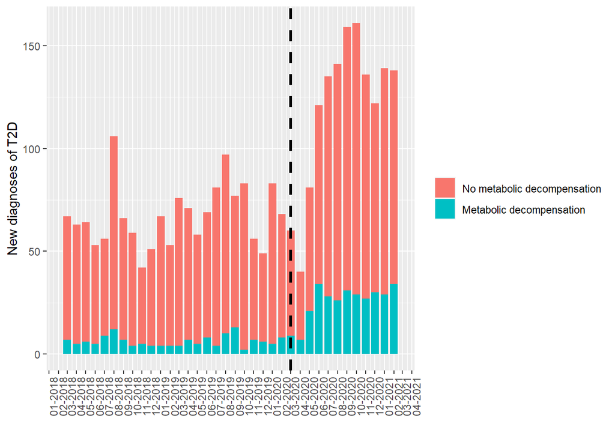

## 4.9 Model diagnostics - T2D cases

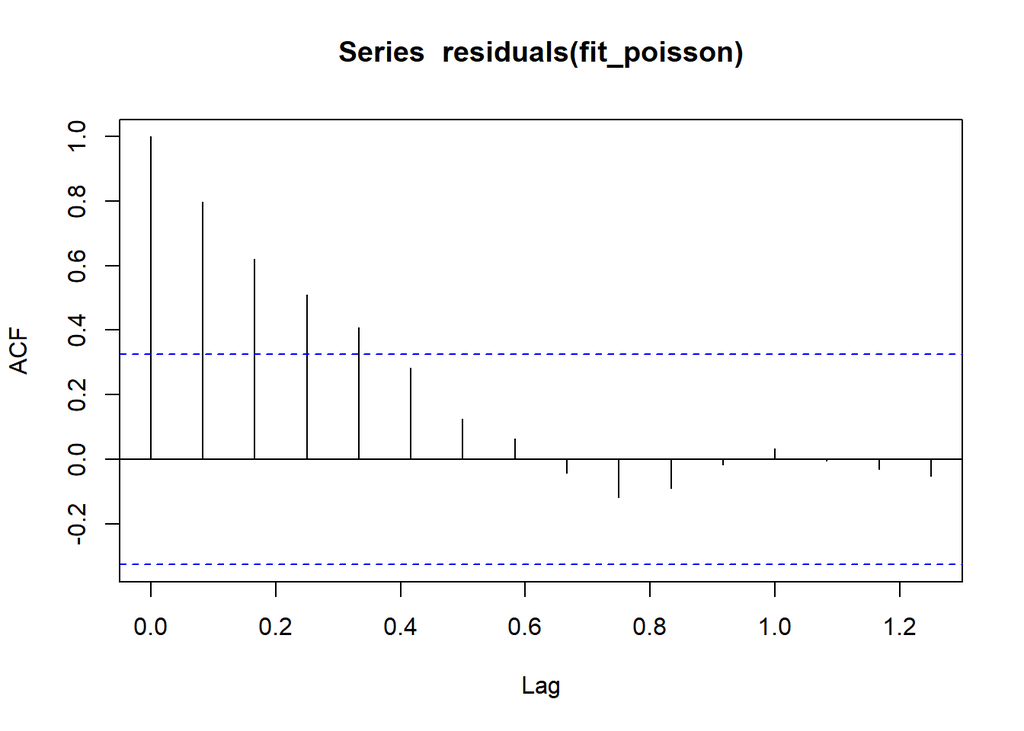

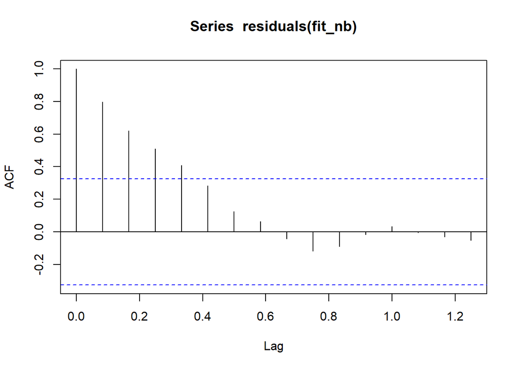

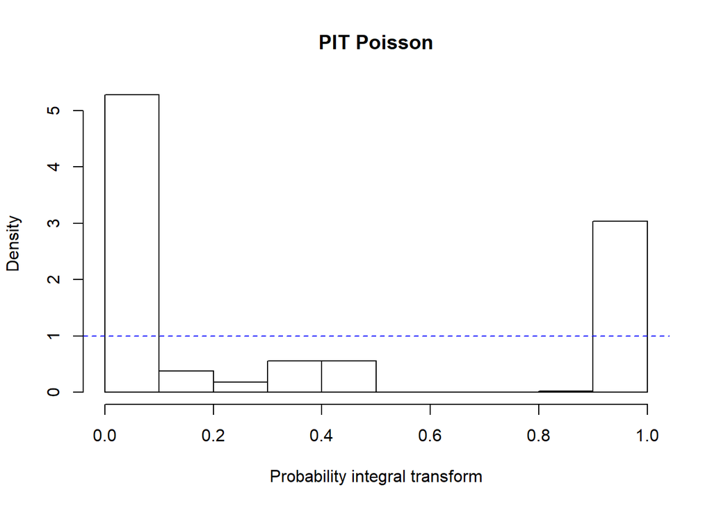

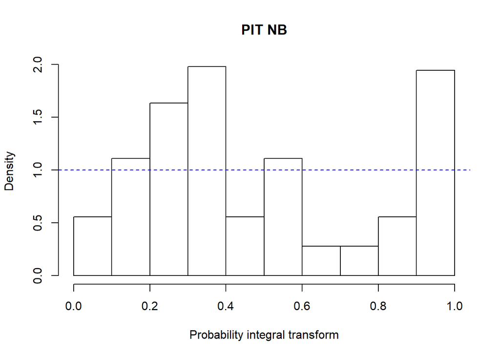

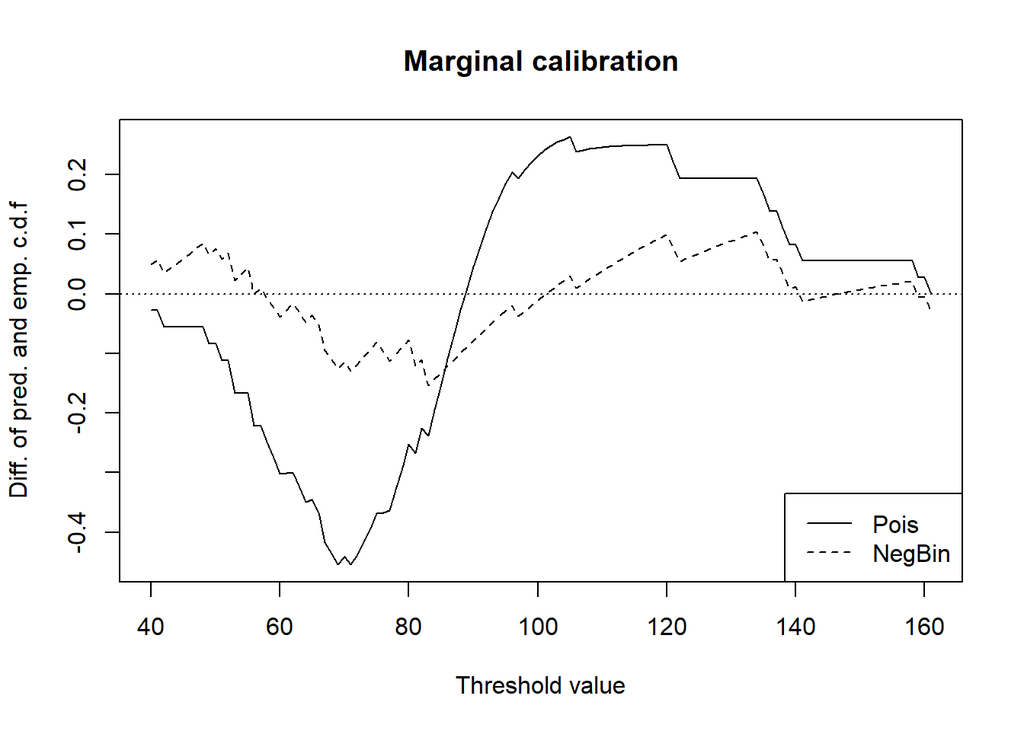

## 4.10 Model results - T2D cases

The parameter estimate corresponding to the test of intervention is labeled “interv_1.” It can be interpreted as the additive effect of the intervention, although interpretation is complicated by the fact that the additive effect enters the dynamic process and is no longer strictly additive.

```
    Score test on intervention(s) of given type at given time

Chisq-Statistic: 15.36582 on 1 degree(s) of freedom, p-value: 8.857627e-05

Fitted model with the specified intervention:

Call:
tsglm(ts = fit$ts, model = model_extended, xreg = xreg_extended,
    link = fit$link, distr = fit$distr)

Coefficients:
(Intercept)       beta_1  linearTrend     interv_1
    20.7832       0.6648       3.2984      15.2721

Overdispersion coefficient 'sigmasq' was estimated to be 0.05179001.
```

## 4.11 Model results - Metabolic decompensation

The parameter estimate corresponding to the test of intervention is labeled “interv_1.” It can be interpreted as the additive effect of the intervention, although interpretation is complicated by the fact that the additive effect enters the dynamic process and is no longer strictly additive.

```
Warning in se.tsglm(object, B = B, parallel = parallel, level = level): The overdispersion coefficient 'sigmasq' could not be estimated
in 3 of the 200 replications. It is set to zero for these
replications. This might to some extent result in a biased estimation
of its true variability.
```

```
    Score test on intervention(s) of given type at given time

Chisq-Statistic: 9.662053 on 1 degree(s) of freedom, p-value: 0.001881132

Fitted model with the specified intervention:

Call:
tsglm(ts = fit$ts, model = model_extended, xreg = xreg_extended,
    link = fit$link, distr = fit$distr)

Coefficients:
(Intercept)       beta_1  linearTrend     interv_1
     2.2973       0.6369       0.2486       7.0067

Overdispersion coefficient 'sigmasq' was estimated to be 0.04865507.
```